# 03. CTmax_analysis_resp_analysis

### MCMC diagnostics

```r
stan_trace(model1.gamk4$fit)
```

```
## 'pars' not specified. Showing first 10 parameters by default.
```

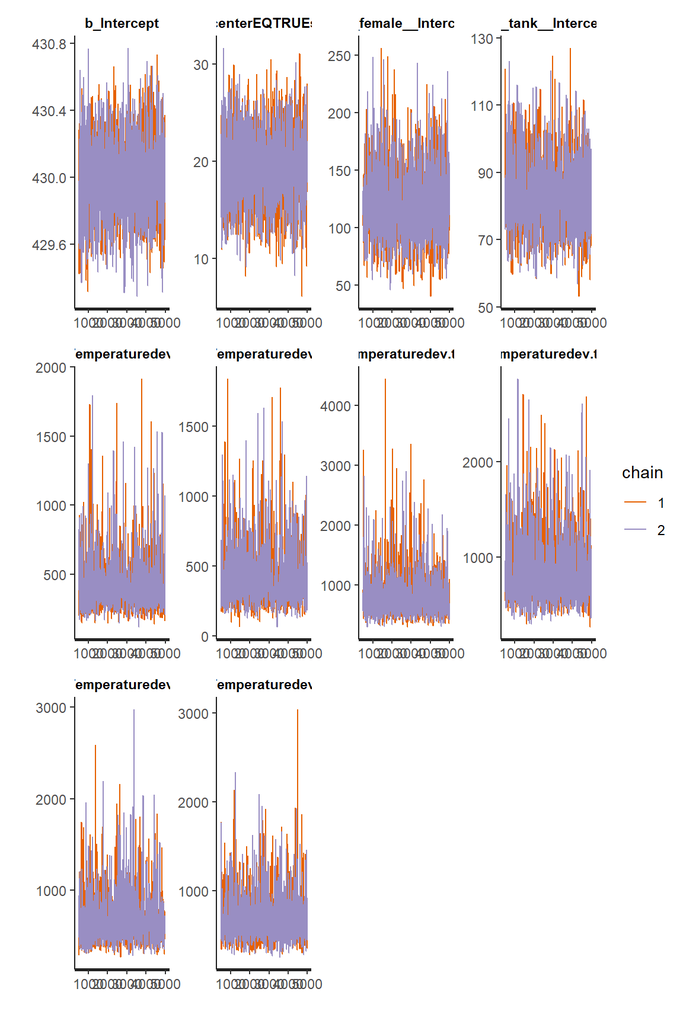

```r
stan_ac(model1.gamk4$fit)
```

```
## 'pars' not specified. Showing first 10 parameters by default.
```

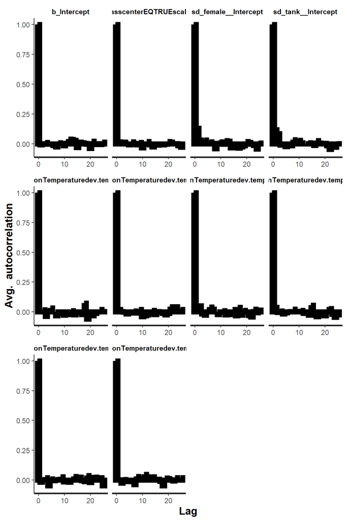

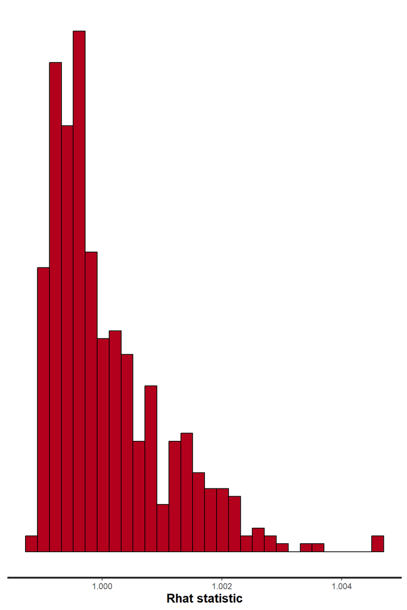

```r
stan_rhat(model1.gamk4$fit)
```

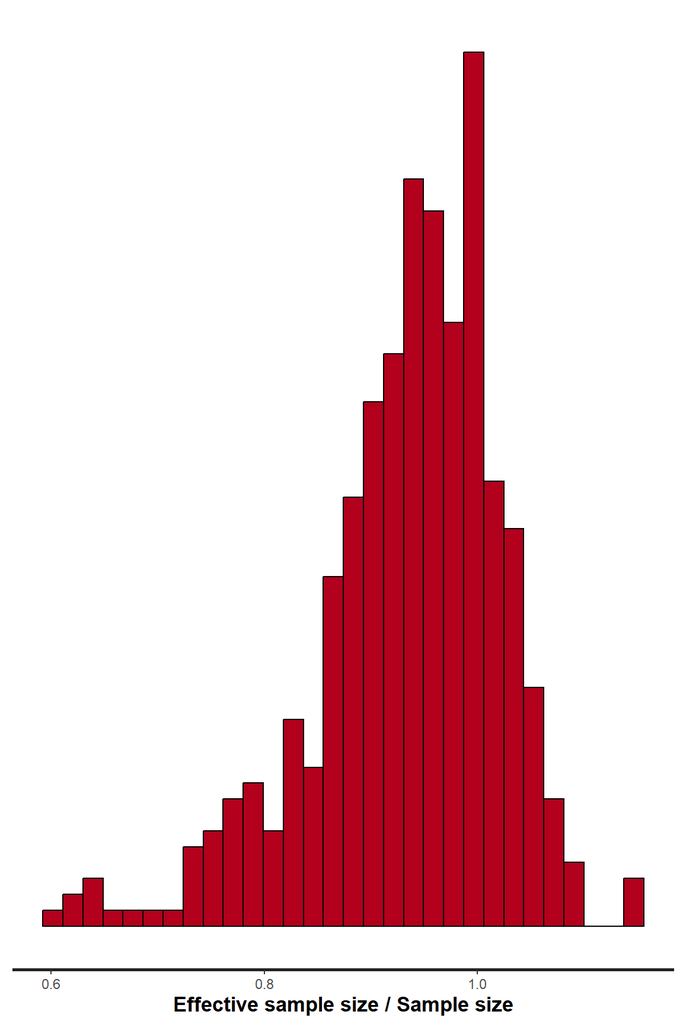

```r
stan_ess(model1.gamk4$fit)
```

```r
stan_dens(model1.gamk4$fit, separate_chains = TRUE)
```

```
## 'pars' not specified. Showing first 10 parameters by default.
```

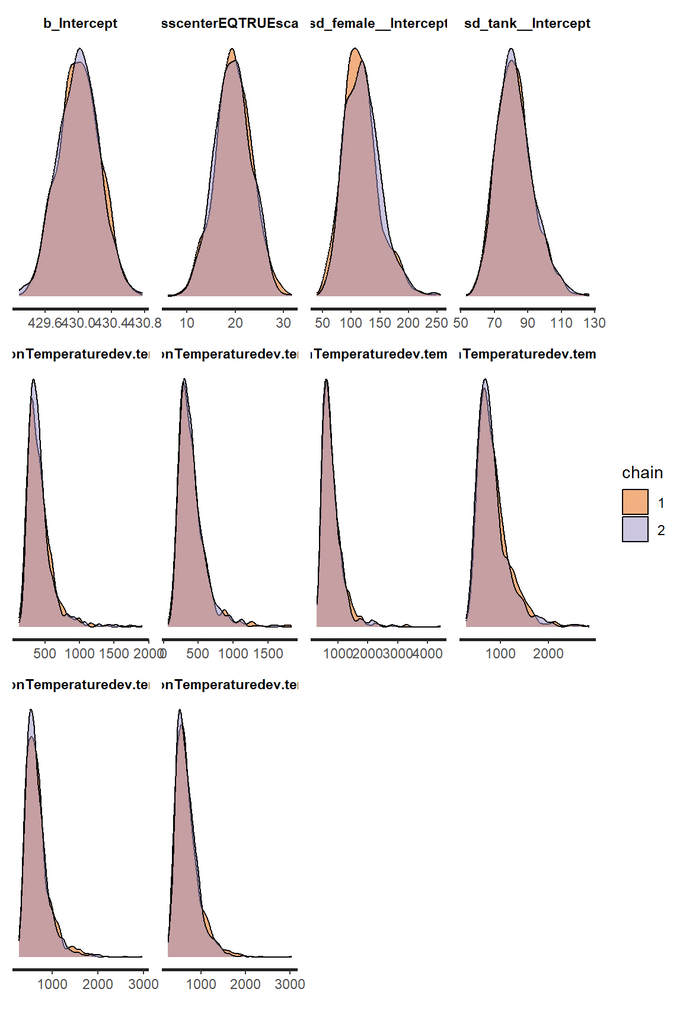

### {-}

## GAM model k=3

### GAM model k=3

```r
f.model1.gamk3 <- bf(rate.output ~ 1 +
                         t2(dev.temp,region,Temperature, k=3, bs="fs", by=dev.temp.region) +
                         scale(mass, center=TRUE, scale=TRUE) +
                         (1| female) + (1| tank),
                         family=gaussian())

model1.gamk3 <- brm(f.model1.gamk3,
              data = lat_resp_dat2,
              prior = rate.priors,
              warmup = 500,
              iter = 5000,
              seed=123,
              cores=2,
              save_pars = save_pars(all=TRUE),
              sample_prior = "yes",
              chains = 2,
              thin = 5,
              control = list(adapt_delta=0.95))
saveRDS(model1.gamk3, file="./03.CTmax_resp_data_analsyis_files/model1.gamk3.RDS")
```

### DHARMa

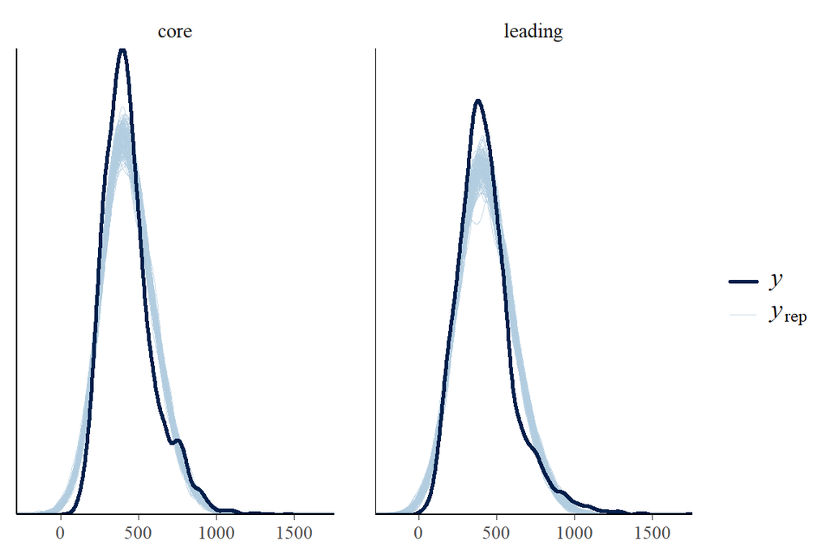

```r
#--- distribution check ---#
pp_check(model1.gamk3, type = 'dens_overlay_grouped', ndraws=150, group="region")
```

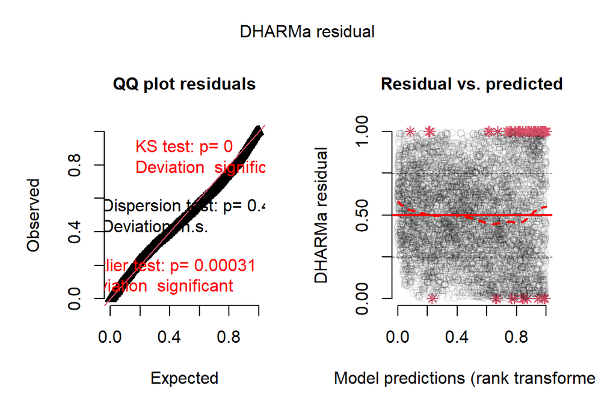

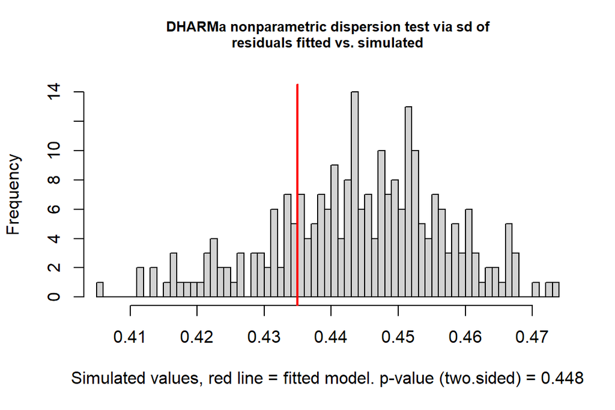

```
##
##  DHARMa nonparametric dispersion test via sd of residuals fitted vs.
##  simulated
##
## data:  simulationOutput
## dispersion = 0.97942, p-value = 0.448
## alternative hypothesis: two.sided
```

```r
#--- DHARMa checks ---#
preds <- posterior_predict(model1.gamk3, ndraws=250, summary=FALSE)
model1.gamk3_resids <- createDHARMa(simulatedResponse = t(preds),
                              observedResponse = lat_resp_dat2$rate.output,
                              fittedPredictedResponse = apply(preds, 2, mean),
                              integerResponse = 'student')
plot(model1.gamk3_resids) ; testDispersion(model1.gamk3_resids)
```

### MCMC diagnostics

```r
stan_trace(model1.gamk3$fit)
```

```
## 'pars' not specified. Showing first 10 parameters by default.
```

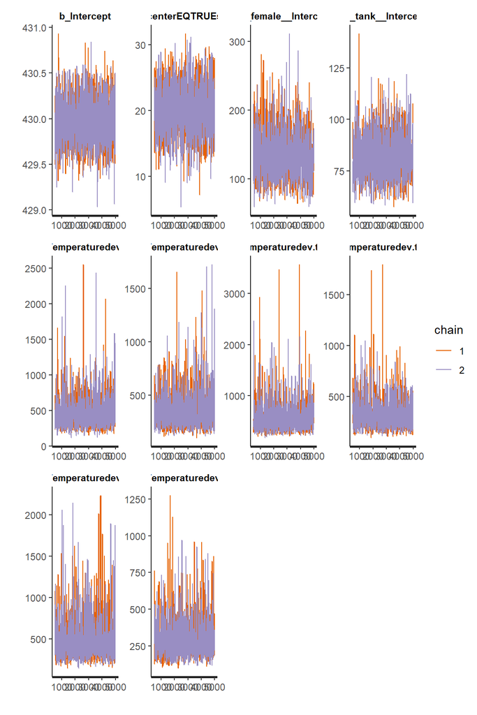

```r
stan_ac(model1.gamk3$fit)
```

```
## 'pars' not specified. Showing first 10 parameters by default.
```

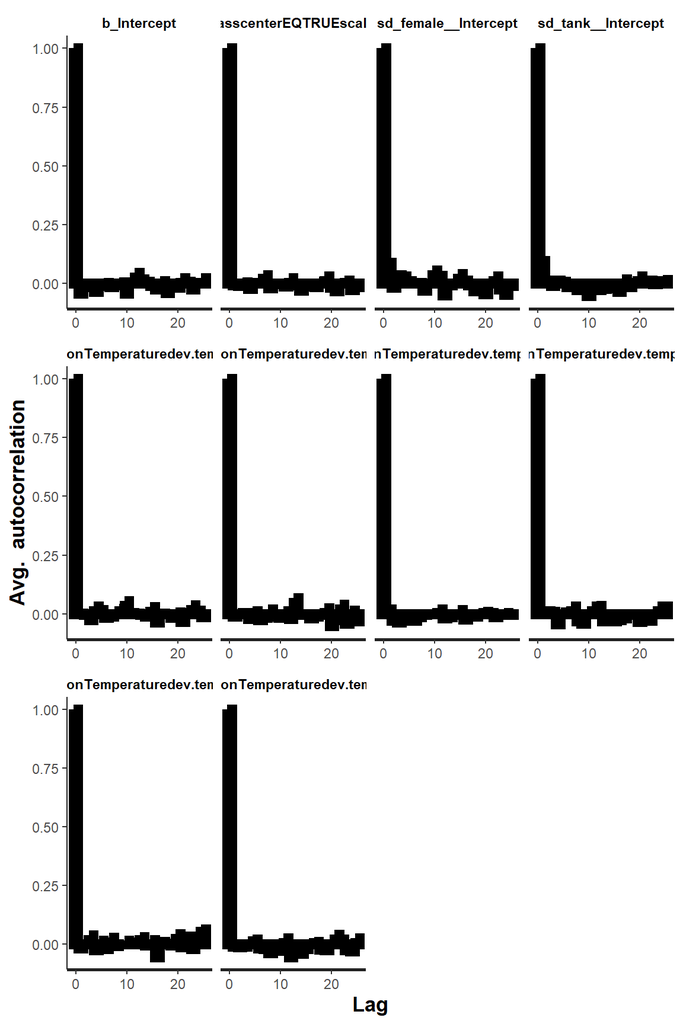

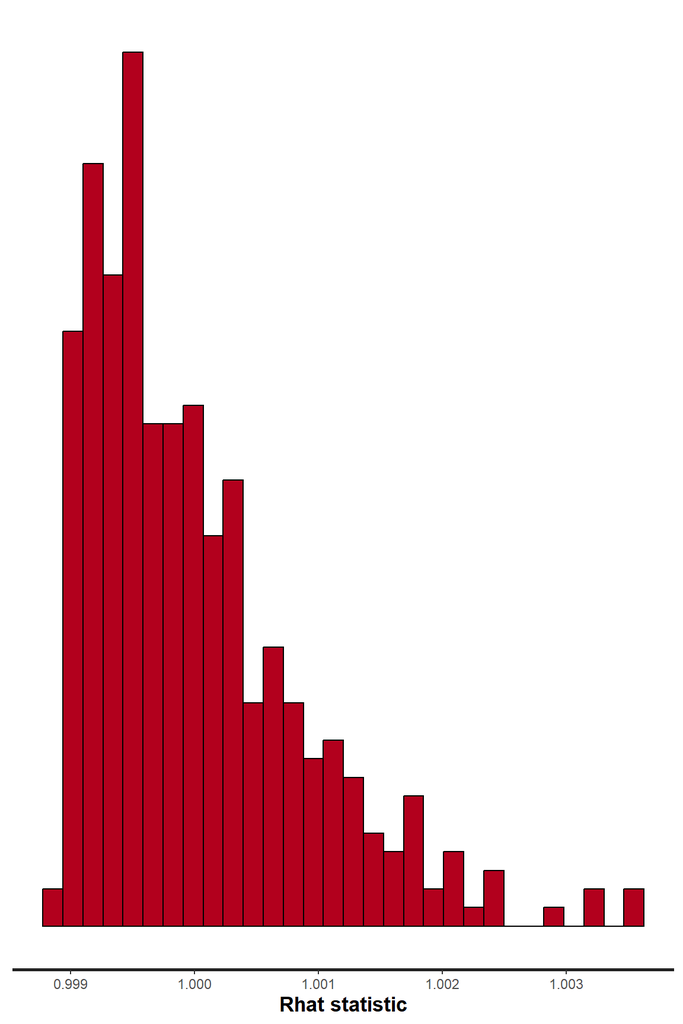

```r
stan_rhat(model1.gamk3$fit)
```

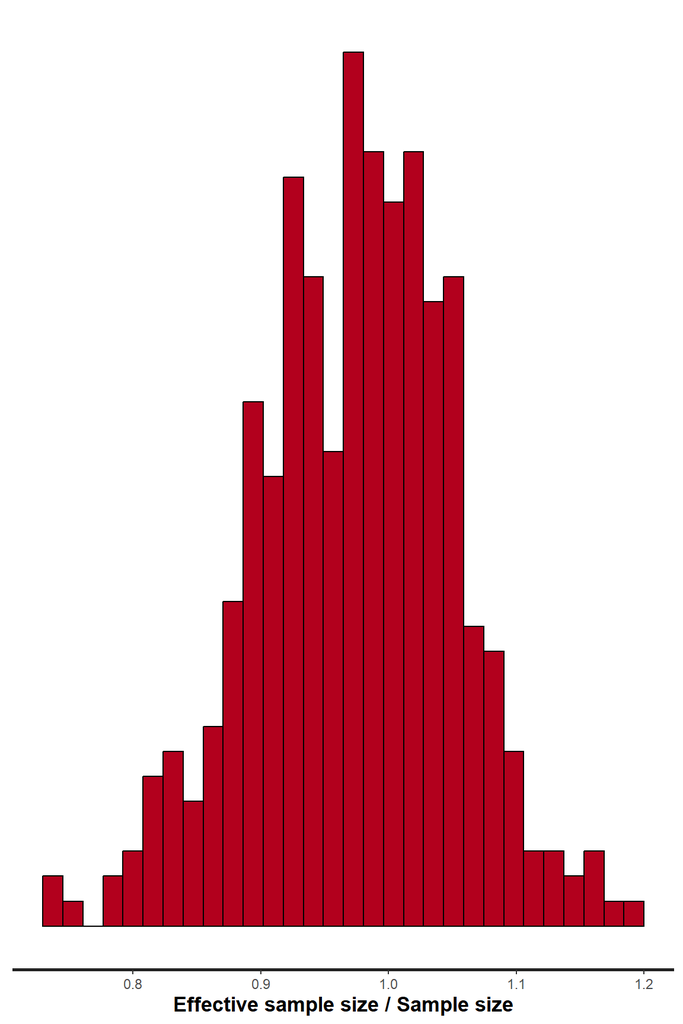

```r
stan_ess(model1.gamk3$fit)
```

```r
stan_dens(model1.gamk3$fit, separate_chains = TRUE)
```

```
## 'pars' not specified. Showing first 10 parameters by default.
```

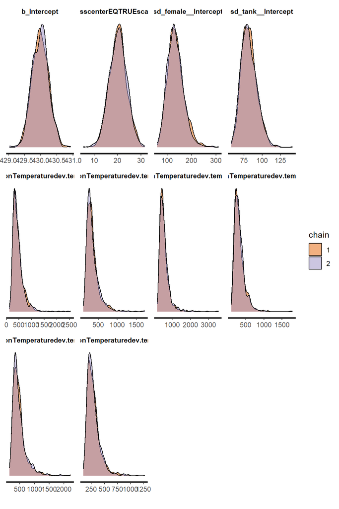

### {-}

```r
AIC(model1.gamk3, model1.gamk4)
```

|  | df | AIC |
| --- | --- | --- |
| model1.gamk3 | -5.666489 | 0.01924393 |
| model1.gamk4 | -5.957441 | -0.36106299 |

# Partial effects plots

## conditional_effects

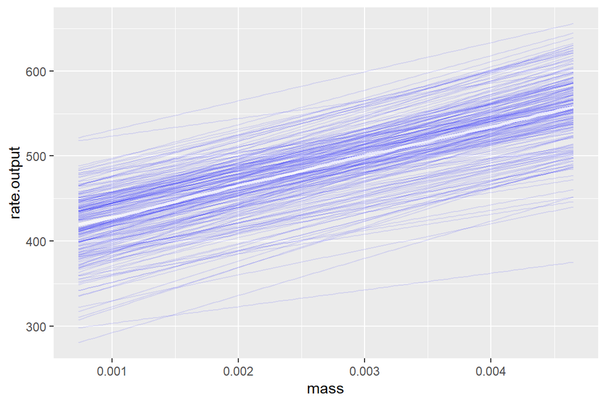

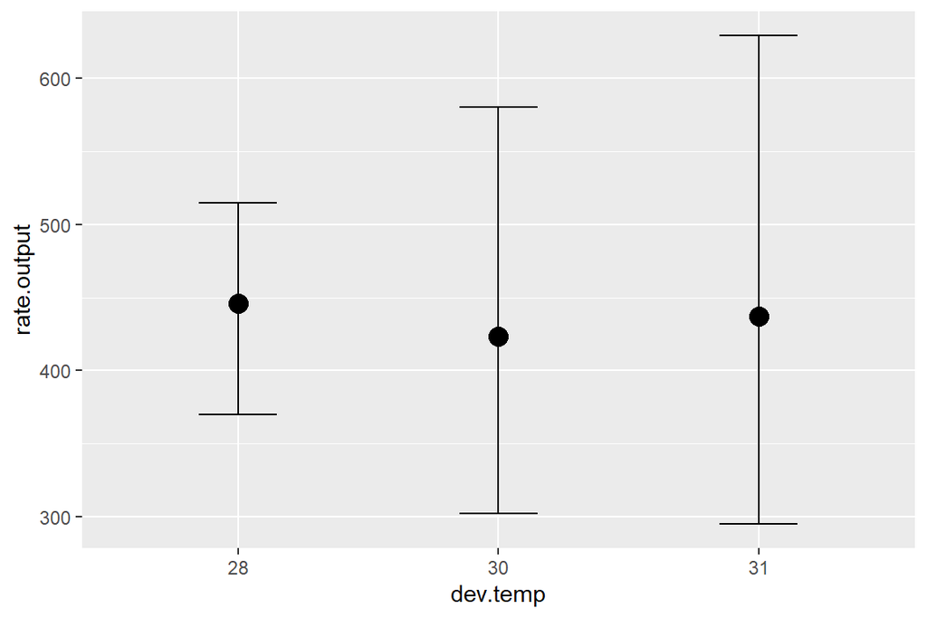

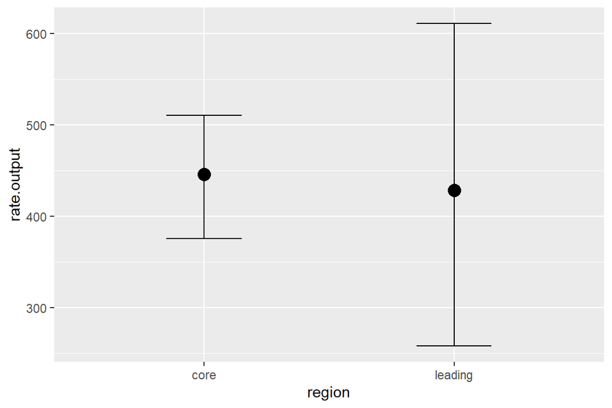

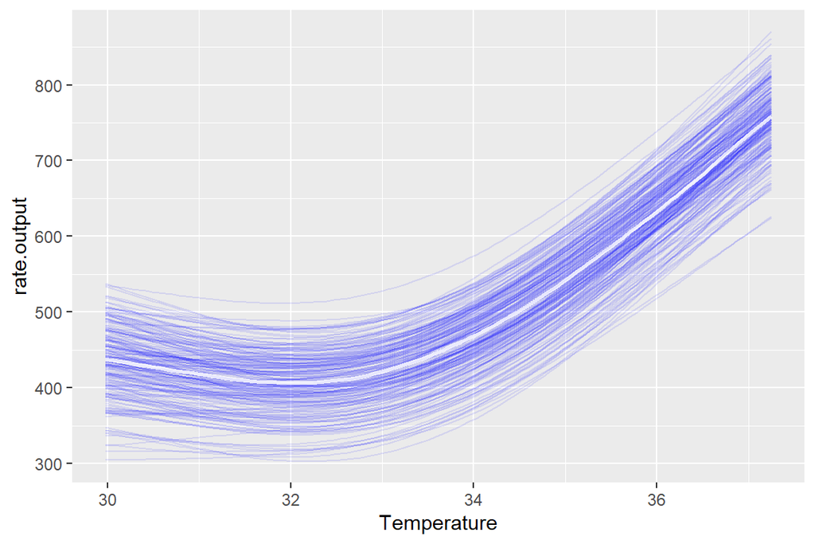

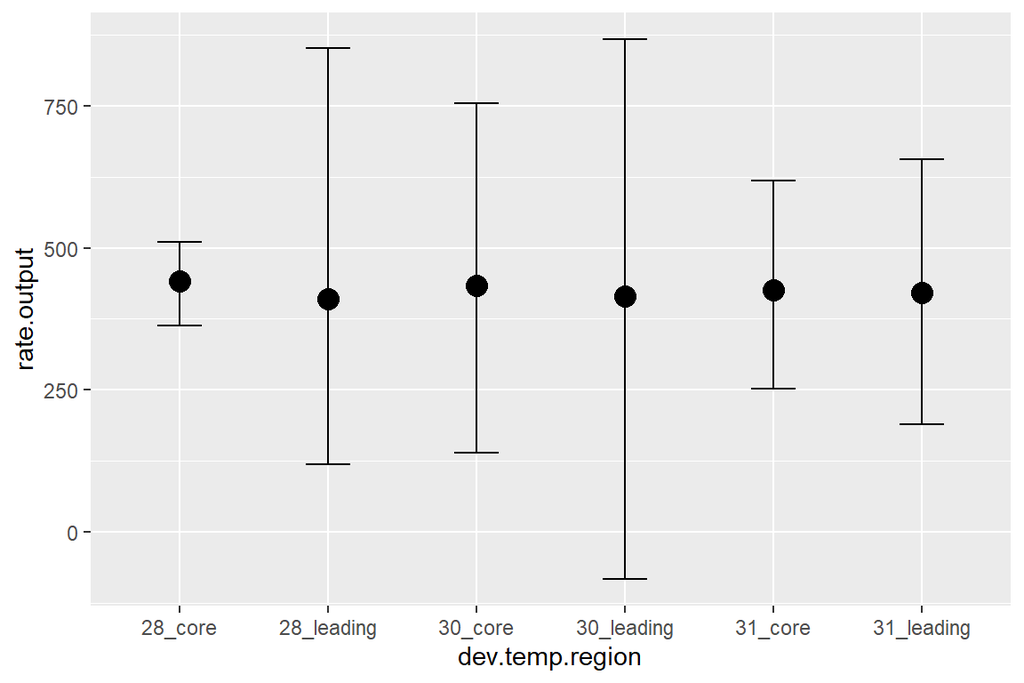

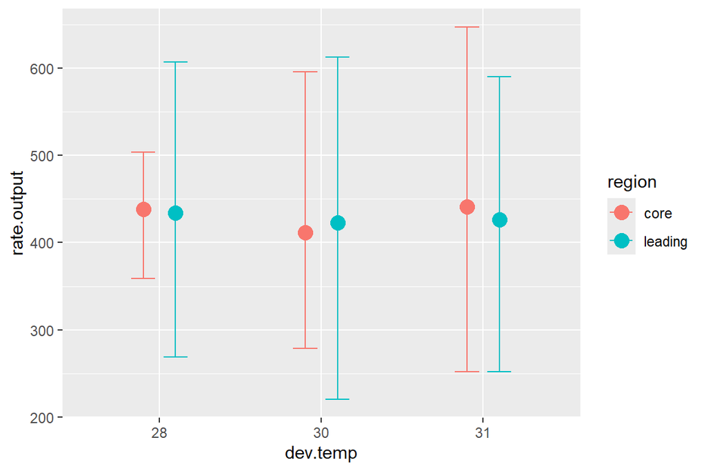

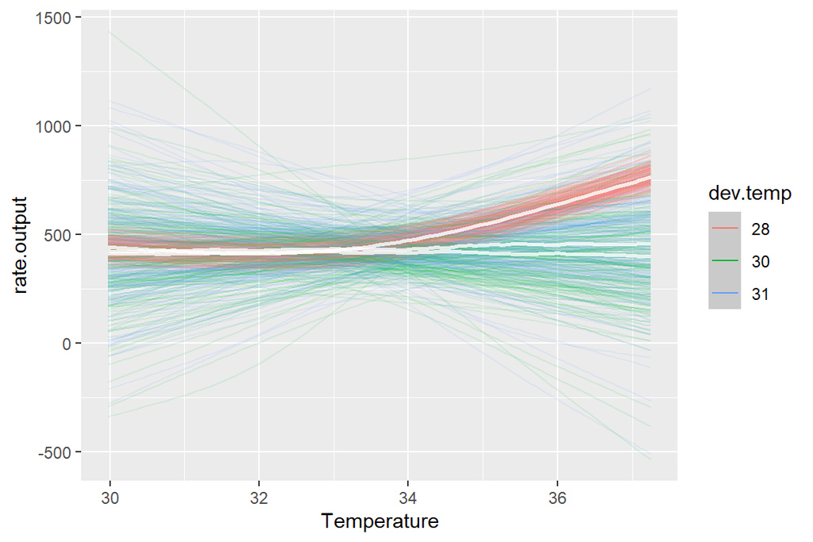

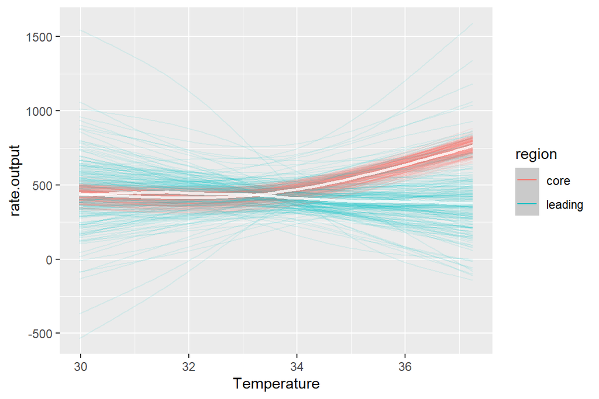

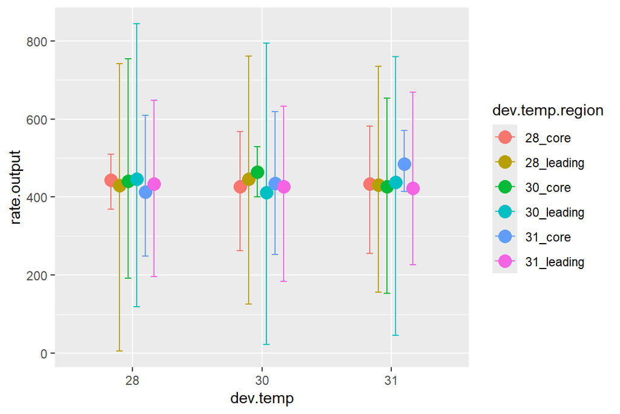

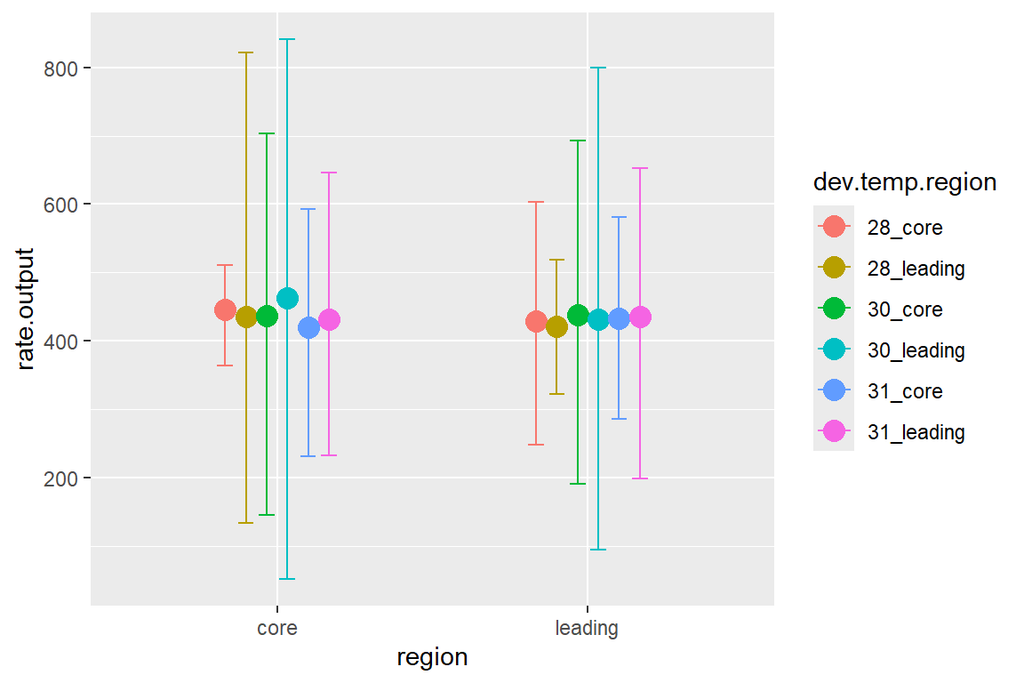

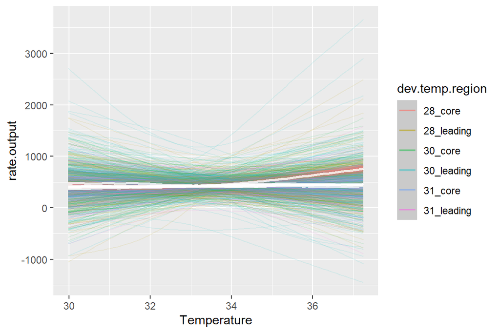

```r
model1.gamk4 |>
  conditional_effects(spaghetti = TRUE, ndraws=200)
```

# Model investigation

## summary

```r
summary(model1.gamk4)
```

```
##  Family: gaussian
##   Links: mu = identity; sigma = identity
## Formula: rate.output ~ 1 + t2(dev.temp, region, Temperature, k = 4, bs = "fs", by = dev.temp.region) + scale(mass, center = TRUE, scale = TRUE) + (1 | female) + (1 | tank)
##    Data: lat_resp_dat2 (Number of observations: 4776)
##   Draws: 2 chains, each with iter = 5000; warmup = 500; thin = 5;
##          total post-warmup draws = 1800
##
## Smooth Terms:
##                                                             Estimate Est.Error
## sds(t2dev.tempregionTemperaturedev.temp.region28_core_1)      420.23    192.27
## sds(t2dev.tempregionTemperaturedev.temp.region28_core_2)      409.00    203.52
## sds(t2dev.tempregionTemperaturedev.temp.region28_leading_1)   807.91    370.10
## sds(t2dev.tempregionTemperaturedev.temp.region28_leading_2)   838.69    338.93
## sds(t2dev.tempregionTemperaturedev.temp.region30_core_1)      672.50    274.67
## sds(t2dev.tempregionTemperaturedev.temp.region30_core_2)      685.97    275.46
## sds(t2dev.tempregionTemperaturedev.temp.region30_leading_1)   910.31    389.52
## sds(t2dev.tempregionTemperaturedev.temp.region30_leading_2)   989.69    425.40
## sds(t2dev.tempregionTemperaturedev.temp.region31_core_1)      423.24    186.68
## sds(t2dev.tempregionTemperaturedev.temp.region31_core_2)      454.59    194.73
## sds(t2dev.tempregionTemperaturedev.temp.region31_leading_1)   592.65    257.89
## sds(t2dev.tempregionTemperaturedev.temp.region31_leading_2)   543.84    236.79
##                                                             l-95% CI u-95% CI
## sds(t2dev.tempregionTemperaturedev.temp.region28_core_1)      204.95   935.83
## sds(t2dev.tempregionTemperaturedev.temp.region28_core_2)      166.01   941.29
## sds(t2dev.tempregionTemperaturedev.temp.region28_leading_1)   392.88  1758.28
## sds(t2dev.tempregionTemperaturedev.temp.region28_leading_2)   413.66  1700.17
## sds(t2dev.tempregionTemperaturedev.temp.region30_core_1)      350.27  1420.75
## sds(t2dev.tempregionTemperaturedev.temp.region30_core_2)      338.90  1390.80
## sds(t2dev.tempregionTemperaturedev.temp.region30_leading_1)   457.39  1876.23
## sds(t2dev.tempregionTemperaturedev.temp.region30_leading_2)   482.79  2114.40
## sds(t2dev.tempregionTemperaturedev.temp.region31_core_1)      202.85   861.71
## sds(t2dev.tempregionTemperaturedev.temp.region31_core_2)      217.51   970.44
## sds(t2dev.tempregionTemperaturedev.temp.region31_leading_1)   291.71  1249.28
## sds(t2dev.tempregionTemperaturedev.temp.region31_leading_2)   264.18  1129.12
##                                                             Rhat Bulk_ESS
## sds(t2dev.tempregionTemperaturedev.temp.region28_core_1)    1.00     1819
## sds(t2dev.tempregionTemperaturedev.temp.region28_core_2)    1.00     1648
## sds(t2dev.tempregionTemperaturedev.temp.region28_leading_1) 1.00     1630
## sds(t2dev.tempregionTemperaturedev.temp.region28_leading_2) 1.00     1600
## sds(t2dev.tempregionTemperaturedev.temp.region30_core_1)    1.00     1741
```

[output cut: 30 more lines]

```
## Population-Level Effects:
##                                  Estimate Est.Error l-95% CI u-95% CI Rhat
## Intercept                          430.00      0.24   429.54   430.47 1.00
## scalemasscenterEQTRUEscaleEQTRUE    19.55      3.77    12.02    26.65 1.00
##                                  Bulk_ESS Tail_ESS
## Intercept                            1801     1707
## scalemasscenterEQTRUEscaleEQTRUE     1683     1613
##
## Family Specific Parameters:
##       Estimate Est.Error l-95% CI u-95% CI Rhat Bulk_ESS Tail_ESS
## sigma   114.35      1.19   111.99   116.71 1.00     1771     1784
##
## Draws were sampled using sampling(NUTS). For each parameter, Bulk_ESS
## and Tail_ESS are effective sample size measures, and Rhat is the potential
## scale reduction factor on split chains (at convergence, Rhat = 1).
```

```r
#car::Anova(model1.geo.gamma)
```

## R2

```r
model1.gamk4 |> bayes_R2(summary = FALSE) |> median_hdci()
```

| y | ymin | ymax | .width | .point | .interval |
| --- | --- | --- | --- | --- | --- |
| 0.5754773 | 0.5634505 | 0.5877627 | 0.95 | median | hdci |

## tidyMCMC

```r
tidyMCMC(model1.gamk4, estimate.method='median', conf.int=TRUE, conf.method='HPDinterval')
```

| term | estimate | std.error | conf.low | conf.high |
| --- | --- | --- | --- | --- |
| b_Intercept | 4.300044e+02 | 0.2444467 | 4.295348e+02 | 4.304647e+02 |
| b_scalemasscenterEQTRUEscaleEQTRUE | 1.950735e+01 | 3.7657725 | 1.222726e+01 | 2.678304e+01 |
| sd_female__Intercept | 1.156845e+02 | 31.6472951 | 5.887869e+01 | 1.822946e+02 |
| sd_tank__Intercept | 8.129207e+01 | 10.8712157 | 6.131037e+01 | 1.030327e+02 |
| sds_t2dev.tempregionTemperaturedev.temp.region28_core_1 | 3.782222e+02 | 192.2659179 | 1.497095e+02 | 7.760203e+02 |
| sds_t2dev.tempregionTemperaturedev.temp.region28_core_2 | 3.635916e+02 | 203.5173242 | 1.257237e+02 | 8.069422e+02 |
| sds_t2dev.tempregionTemperaturedev.temp.region28_leading_1 | 7.173929e+02 | 370.0968851 | 2.990759e+02 | 1.426367e+03 |
| sds_t2dev.tempregionTemperaturedev.temp.region28_leading_2 | 7.569169e+02 | 338.9343335 | 3.722821e+02 | 1.520748e+03 |
| sds_t2dev.tempregionTemperaturedev.temp.region30_core_1 | 6.113210e+02 | 274.6696071 | 3.090562e+02 | 1.203771e+03 |
| sds_t2dev.tempregionTemperaturedev.temp.region30_core_2 | 6.241167e+02 | 275.4576522 | 2.854264e+02 | 1.225706e+03 |

[output cut: 442 more lines]

## gather draws

```r
#model1.re.wo |> get_variables()
model1.gamk4 |> gather_draws(`b_.*|sigma`, regex =TRUE) |>
  median_hdci()
```

| .variable | .value | .lower | .upper | .width | .point | .interval |
| --- | --- | --- | --- | --- | --- | --- |
| b_Intercept | 430.00445 | 429.53478 | 430.46470 | 0.95 | median | hdci |
| b_scalemasscenterEQTRUEscaleEQTRUE | 19.50735 | 11.76077 | 26.38516 | 0.95 | median | hdci |
| sigma | 114.33225 | 111.94211 | 116.57597 | 0.95 | median | hdci |

## bayesplot

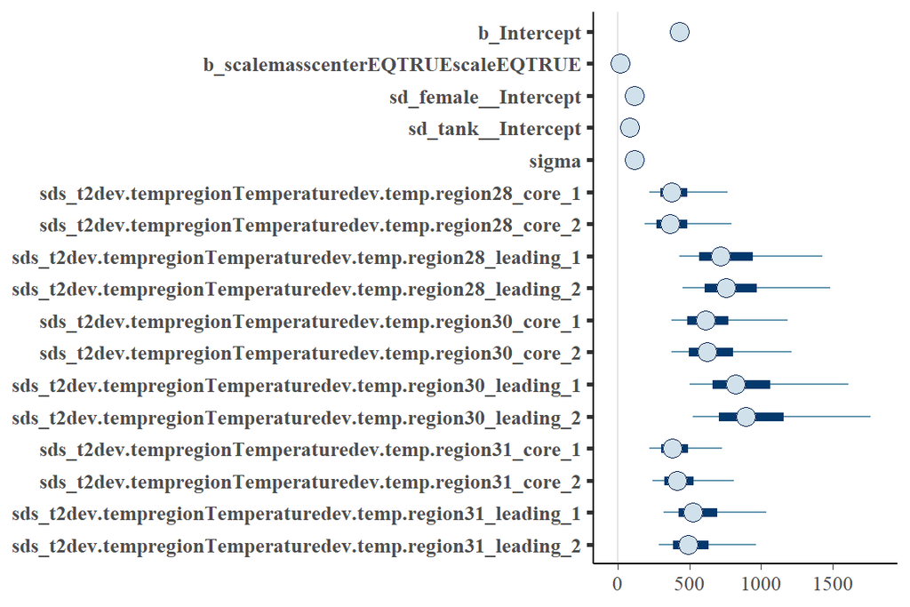

```r
model1.gamk4 |> mcmc_plot(type='intervals')
```

## emmeans - pariwise

```r
model1.gamk4 |> emmeans(pairwise ~ region*dev.temp, type="response") |> pairs(by="dev.temp") |> summary(infer=TRUE)
```

```
## NOTE: A nesting structure was detected in the fitted model:
##     dev.temp.region %in% (dev.temp*region)
```

|  | contrast | dev.temp | estimate | lower.HPD | upper.HPD |
| --- | --- | --- | --- | --- | --- |
| 1 | core - leading | 28 | 20.65952 | -94.74853 | 143.80707 |
| 2 | core - leading | 30 | 67.62172 | -63.76426 | 183.01586 |
| 3 | core - leading | 31 | -10.09269 | -123.21265 | 93.77715 |

```r
model1.gamk4 |> emmeans(pairwise ~ region*dev.temp, type="response") |> pairs(by="region") |> confint()
```

```
## NOTE: A nesting structure was detected in the fitted model:
##     dev.temp.region %in% (dev.temp*region)
```

|  | contrast | region | estimate | lower.HPD | upper.HPD |
| --- | --- | --- | --- | --- | --- |
| 1 | dev.temp28 - dev.temp30 | core | -26.724371 | -97.76297 | 43.673722 |
| 2 | dev.temp28 - dev.temp31 | core | -35.668833 | -106.20261 | 43.797760 |
| 3 | dev.temp30 - dev.temp31 | core | -8.581086 | -76.89438 | 65.047550 |
| 4 | dev.temp28 - dev.temp30 | leading | 15.339225 | -57.18254 | 104.213941 |
| 5 | dev.temp28 - dev.temp31 | leading | -65.265672 | -138.13859 | 7.934584 |
| 6 | dev.temp30 - dev.temp31 | leading | -82.702493 | -158.83295 | -8.870458 |

```r
model1.gamk4 |> emmeans(pairwise ~ region*dev.temp, type="response") |> regrid()
```

```
## NOTE: A nesting structure was detected in the fitted model:
##     dev.temp.region %in% (dev.temp*region)
```

```
##  region  dev.temp emmean lower.HPD upper.HPD
##  core    28          444       367       511
##  leading 28          419       303       511
##  core    30          467       399       538
##  leading 30          399       295       512
##  core    31          477       400       547
##  leading 31          485       393       577
##
## Point estimate displayed: median
## HPD interval probability: 0.95
```

```r
model1.gamk4 |> emmeans(pairwise ~ region*dev.temp, type="response") |> pairs(by="region") |> confint()
```

```
## NOTE: A nesting structure was detected in the fitted model:
##     dev.temp.region %in% (dev.temp*region)
```

|  | contrast | region | estimate | lower.HPD | upper.HPD |
| --- | --- | --- | --- | --- | --- |
| 1 | dev.temp28 - dev.temp30 | core | -26.724371 | -97.76297 | 43.673722 |
| 2 | dev.temp28 - dev.temp31 | core | -35.668833 | -106.20261 | 43.797760 |
| 3 | dev.temp30 - dev.temp31 | core | -8.581086 | -76.89438 | 65.047550 |
| 4 | dev.temp28 - dev.temp30 | leading | 15.339225 | -57.18254 | 104.213941 |
| 5 | dev.temp28 - dev.temp31 | leading | -65.265672 | -138.13859 | 7.934584 |
| 6 | dev.temp30 - dev.temp31 | leading | -82.702493 | -158.83295 | -8.870458 |

## emtrenns - pariwise

```r
emtrends(model1.gamk4, specs=pairwise~dev.temp*region, var = "Temperature")
```

```
## NOTE: A nesting structure was detected in the fitted model:
##     dev.temp.region %in% (dev.temp*region)
```

```
## $emtrends
##  dev.temp region  Temperature.trend lower.HPD upper.HPD
##  28       core               44.872     31.78      57.1
##  30       core                2.862     -8.80      15.7
##  31       core               24.090     13.29      35.6
##  28       leading            -0.815    -14.74      12.8
##  30       leading             1.168    -13.99      16.4
##  31       leading             7.000     -5.06      19.1
##
## Point estimate displayed: median
## HPD interval probability: 0.95
##
## $contrasts
##  contrast                                estimate lower.HPD upper.HPD
##  dev.temp28 core - dev.temp30 core          42.04    24.173     60.14
##  dev.temp28 core - dev.temp31 core          20.95     4.017     38.19
##  dev.temp28 core - dev.temp28 leading       45.62    26.541     63.58
##  dev.temp28 core - dev.temp30 leading       43.94    25.948     64.08
##  dev.temp28 core - dev.temp31 leading       38.00    20.584     55.40
##  dev.temp30 core - dev.temp31 core         -21.32   -37.216     -3.77
##  dev.temp30 core - dev.temp28 leading        3.65   -14.587     23.10
##  dev.temp30 core - dev.temp30 leading        1.71   -16.474     22.04
##  dev.temp30 core - dev.temp31 leading       -4.18   -20.285     13.35
##  dev.temp31 core - dev.temp28 leading       24.81     6.454     42.12
##  dev.temp31 core - dev.temp30 leading       23.23     5.496     42.63
##  dev.temp31 core - dev.temp31 leading       17.00    -0.205     32.99
##  dev.temp28 leading - dev.temp30 leading    -1.55   -20.579     19.27
##  dev.temp28 leading - dev.temp31 leading    -7.62   -25.674     10.96
##  dev.temp30 leading - dev.temp31 leading    -6.18   -25.762     12.80
##
## Point estimate displayed: median
## HPD interval probability: 0.95
```

## probabilities

```r
mtsqst <- model1.gamk4 |> emmeans(pairwise ~ region*dev.temp)
```

```
## NOTE: A nesting structure was detected in the fitted model:
##     dev.temp.region %in% (dev.temp*region)
```

```r
mtsqrt2 <- mtsqst$contrasts |> gather_emmeans_draws()
mtsqrt2 %>% group_by(contrast) %>% dplyr::summarise(Prob = sum(.value>0)/n())
```

| contrast | Prob |
| --- | --- |
| core dev.temp28 - core dev.temp30 | 0.23611111 |
| core dev.temp28 - core dev.temp31 | 0.17555556 |
| core dev.temp28 - leading dev.temp28 | 0.63888889 |
| core dev.temp28 - leading dev.temp30 | 0.73611111 |
| core dev.temp28 - leading dev.temp31 | 0.21611111 |
| core dev.temp30 - core dev.temp31 | 0.40611111 |
| core dev.temp30 - leading dev.temp30 | 0.84666667 |
| core dev.temp30 - leading dev.temp31 | 0.37666667 |
| core dev.temp31 - leading dev.temp31 | 0.43444444 |
| leading dev.temp28 - core dev.temp30 | 0.21722222 |

[output cut: 5 more lines]

# summary figure

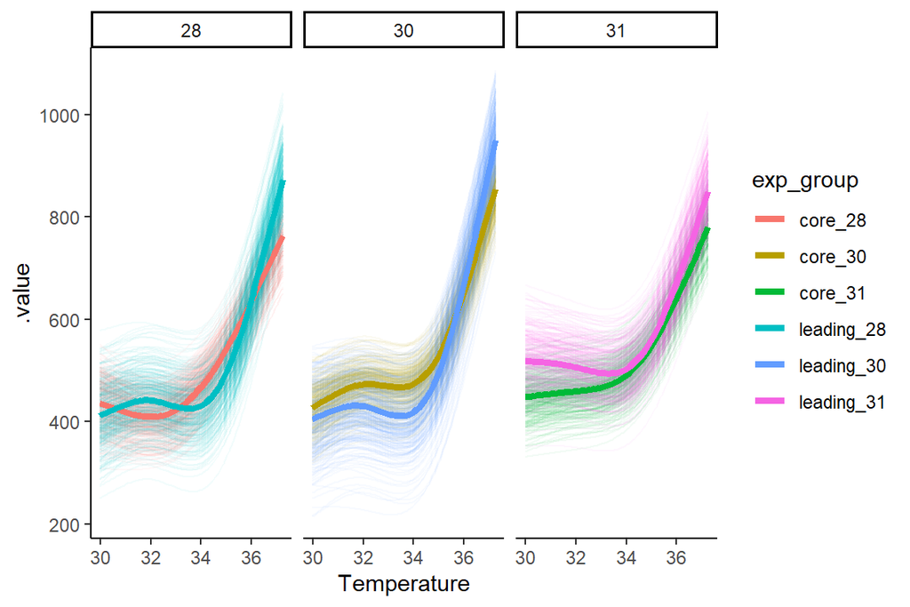

```r
resp.plot <- lat_resp_dat2 |>
  group_by(region, dev.temp,dev.temp.region) |>
  data_grid(Temperature=seq(from=min(lat_resp_dat2$Temperature),
                          to=max(lat_resp_dat2$Temperature),
                          length.out=100),
            mass=0.00148299) |>
  add_fitted_draws(model1.gamk4,
                   n=300,
                   re_formula=NA) |>
  unite("exp_group", c("region","dev.temp"), remove=FALSE) |>
  ggplot(aes(x=Temperature, color=exp_group)) +
  geom_line(aes(y=.value, group=paste(exp_group, .draw)), alpha=0.05) +
  geom_smooth(aes(y=.value, color=exp_group), se=FALSE, size=1.5) +
  theme_classic() +
  facet_wrap(~dev.temp); resp.plot
```

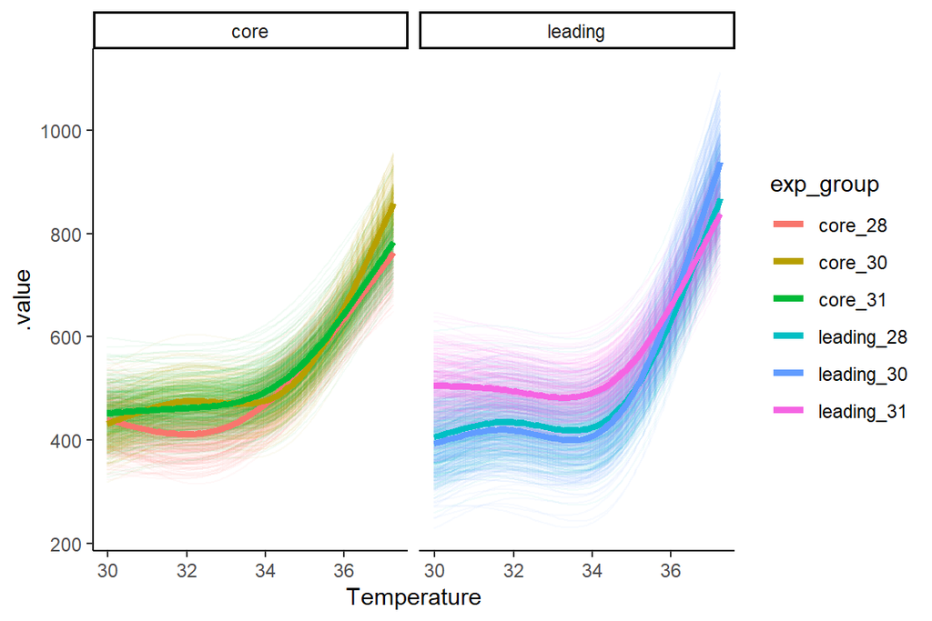

```r
resp.plot2 <- lat_resp_dat2 |>
  group_by(region, dev.temp,dev.temp.region) |>
  data_grid(Temperature=seq(from=min(lat_resp_dat2$Temperature),
                          to=max(lat_resp_dat2$Temperature),
                          length.out=100),
            mass=0.00148299) |>
  add_fitted_draws(model1.gamk4,
                   n=300,
                   re_formula=NA) |>
  unite("exp_group", c("region","dev.temp"), remove=FALSE) |>
  ggplot(aes(x=Temperature, color=exp_group)) +
  geom_line(aes(y=.value, group=paste(exp_group, .draw)), alpha=0.05) +
  geom_smooth(aes(y=.value, color=exp_group), se=FALSE, size=1.5) +
  theme_classic() +
  facet_wrap(~region); resp.plot2
```

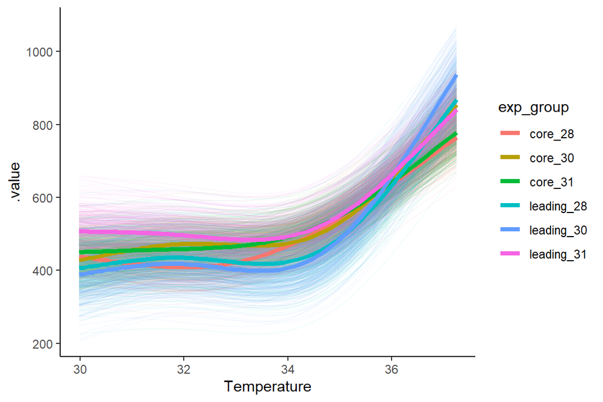

```r
resp.plot3 <- lat_resp_dat2 |>
  group_by(region, dev.temp,dev.temp.region) |>
  data_grid(Temperature=seq(from=min(lat_resp_dat2$Temperature),
                          to=max(lat_resp_dat2$Temperature),
                          length.out=100),
            mass=0.00148299) |>
  add_fitted_draws(model1.gamk4,
                   n=300,
                   re_formula=NA) |>
  unite("exp_group", c("region","dev.temp"), remove=FALSE) |>
  ggplot(aes(x=Temperature, color=exp_group)) +
  geom_line(aes(y=.value, group=paste(exp_group, .draw)), alpha=0.05) +
  geom_smooth(aes(y=.value, color=exp_group), se=FALSE, size=1.5) +
  theme_classic(); resp.plot3
```

# Piecewise linear regression

## Low-latitude - 28.5C

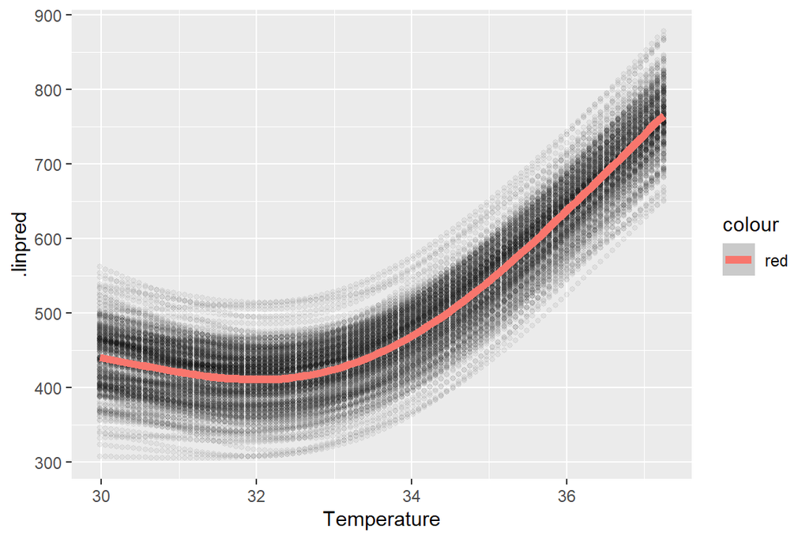

```r
posterior_draws <- lat_resp_dat2 |>
  group_by(region, dev.temp,dev.temp.region) |>
  data_grid(Temperature=seq(from=min(lat_resp_dat2$Temperature),
                          to=max(lat_resp_dat2$Temperature),
                          length.out=100),
            mass=0.00148299) |>
  add_linpred_draws(model1.gamk4,
                   n=300,
                   re_formula=NA) |>
  unite("exp_group", c("region","dev.temp"), remove=FALSE) |>
  filter(dev.temp.region == "28_core")

spline_fit <- smooth.spline(posterior_draws$Temperature, posterior_draws$.linpred, nknots = 4)

ggplot(posterior_draws, aes(x=Temperature, y=.linpred)) +
  geom_point(color="black", alpha=0.05, size=1) +
  geom_smooth(data=as.data.frame(spline_fit$data), aes(x=x, y=y,
                                        color="red"),
              size=2)
```

### strucchange analysis

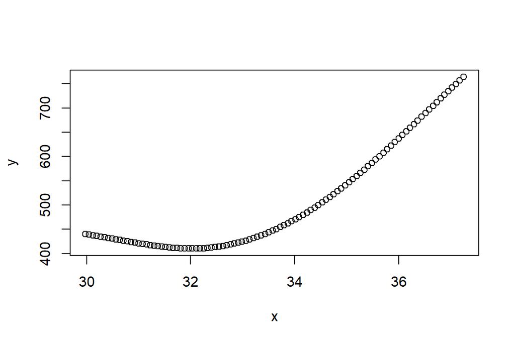

```r
spline.data <- as.data.frame(x= spline_fit$x) |>
  mutate(y = spline_fit$y)|>
  rename(x = `spline_fit$x`)

plot(spline.data)
```

```r
fs.data <- Fstats(spline.data$y~1)
bp.data <- breakpoints(spline.data$y~1)
summary(bp.data)
```

```
##
##   Optimal (m+1)-segment partition:
##
## Call:
## breakpoints.formula(formula = spline.data$y ~ 1)
##
## Breakpoints at observation number:
##
## m = 1            70
## m = 2         60    81
## m = 3         54 70 85
## m = 4      40 55 70 85
## m = 5   15 40 55 70 85
##
## Corresponding to breakdates:
##
## m = 1                 0.7
## m = 2            0.6      0.81
## m = 3            0.54 0.7 0.85
## m = 4        0.4 0.55 0.7 0.85
## m = 5   0.15 0.4 0.55 0.7 0.85
##
## Fit:
##
## m   0         1         2         3         4         5
## RSS 1170431.8  216925.0   88460.8   49097.0   44088.4   41482.4
## BIC    1229.8    1070.4     989.9     940.3     938.7     941.8
```

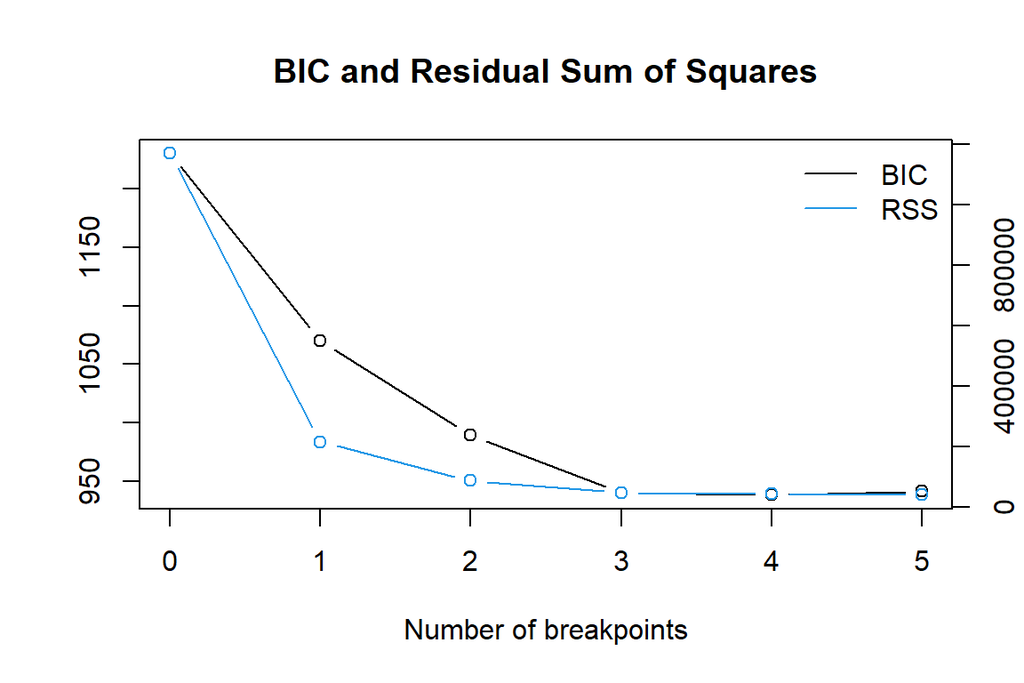

```r
plot(bp.data)
```

```r
breakpoint.values=c(54,70,85); spline.data[breakpoint.values, c("x")]
```

```
## [1] 33.86963 35.04506 36.14703
```

### segement analysis

Use out from strucchange summary to number of breakpoints as well as approximate location of breakpoints

```r
my.lm <- lm(data=spline.data, y ~ x)

spline.data[breakpoint.values, c("x")]
```

```
## [1] 33.86963 35.04506 36.14703
```

```r
my.seg <- segmented(my.lm,
                    seg.Z = ~x,
                    psi=list(x=spline.data[breakpoint.values, c("x")]))
#summary(my.seg)

my.seg$psi ; slope(my.seg)
```

```
##         Initial     Est.     St.Err
## psi1.x 33.86963 32.14501 0.02701804
## psi2.x 35.04506 33.52461 0.02942867
## psi3.x 36.14703 34.93830 0.03209560
```

```
## $x
##           Est. St.Err. t value CI(95%).l CI(95%).u
## slope1 -15.086 0.53064 -28.429   -16.139   -14.032
## slope2  25.029 1.05370  23.754    22.937    27.122
## slope3  65.828 1.05370  62.474    63.736    67.921
## slope4  99.259 0.48165 206.080    98.303   100.220
```

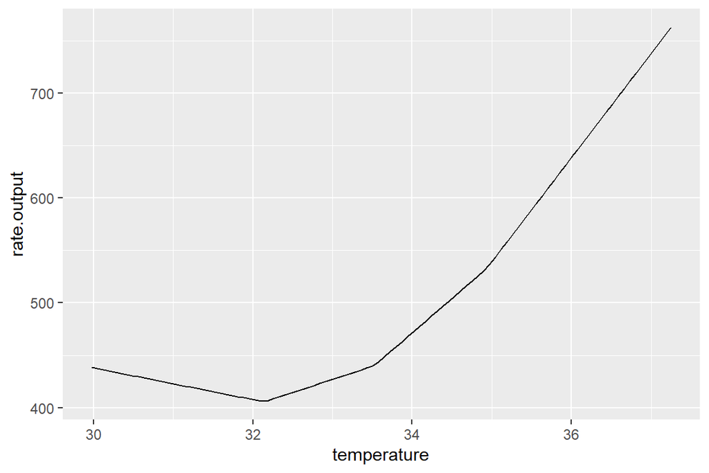

```r
my.fitted <- fitted(my.seg)
my.model <- data.frame(temperature = spline.data$x, rate.output= my.fitted)

ggplot(my.model, aes(x=temperature, y=rate.output)) + geom_line()
```

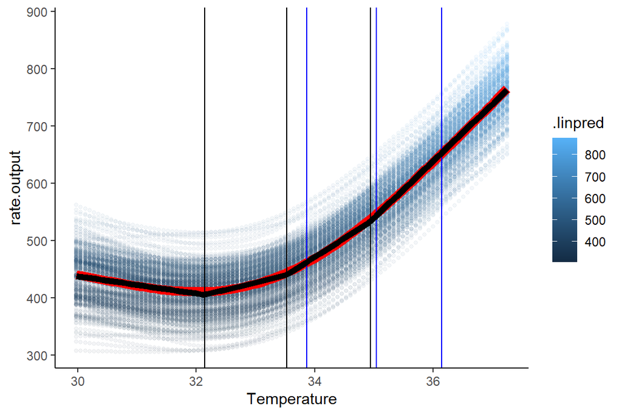

```r
ggplot(posterior_draws, aes(x=Temperature, y=.linpred, color=.linpred)) +
  geom_point(alpha=0.05, size=1) +
  geom_smooth(data=as.data.frame(spline_fit$data), aes(x=x, y=y), color="red",
              size=3) + ylab("rate.output")+
  geom_vline(xintercept = my.seg$psi[1,2]) +
   geom_vline(xintercept = my.seg$psi[2,2])+
  geom_vline(xintercept = my.seg$psi[3,2])+
   geom_vline(xintercept = my.seg$psi[1,1], color="blue") +
  geom_vline(xintercept = my.seg$psi[2,1], color="blue") +
  geom_vline(xintercept = my.seg$psi[3,1], color="blue") +
  geom_line(data=my.model, aes(x=temperature, y=rate.output), color="black", size=2) +
  theme_classic()
```

## Low-latitude - 30C

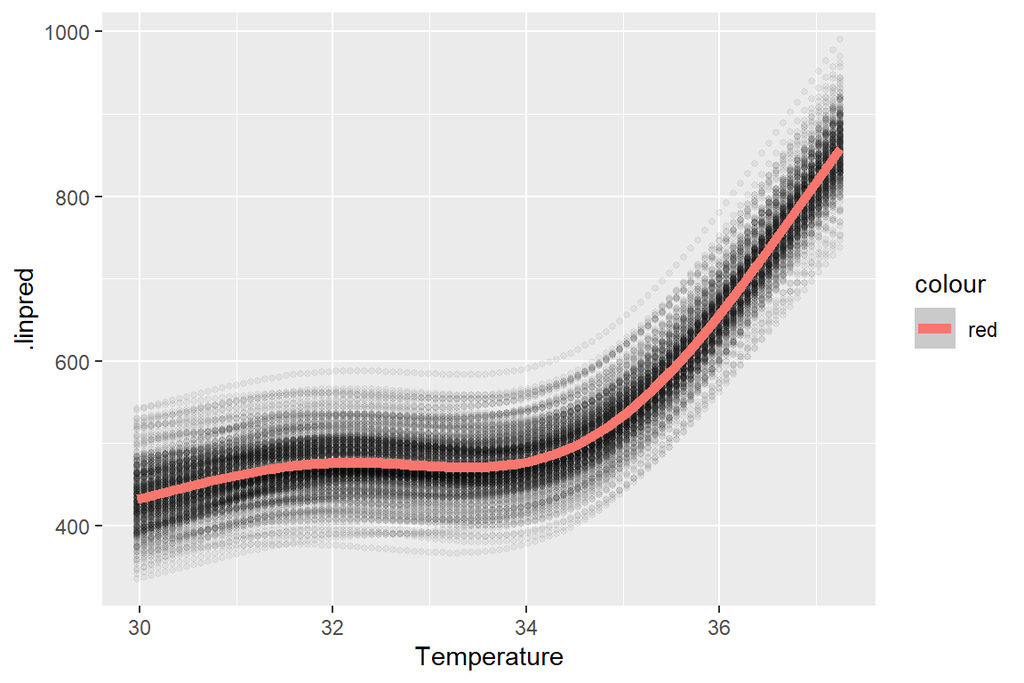

```r
posterior_draws <- lat_resp_dat2 |>
  group_by(region, dev.temp,dev.temp.region) |>
  data_grid(Temperature=seq(from=min(lat_resp_dat2$Temperature),
                          to=max(lat_resp_dat2$Temperature),
                          length.out=100),
            mass=0.00148299) |>
  add_linpred_draws(model1.gamk4,
                   n=300,
                   re_formula=NA) |>
  unite("exp_group", c("region","dev.temp"), remove=FALSE) |>
  filter(dev.temp.region == "30_core")

spline_fit <- smooth.spline(posterior_draws$Temperature, posterior_draws$.linpred, nknots = 4)

ggplot(posterior_draws, aes(x=Temperature, y=.linpred)) +
  geom_point(color="black", alpha=0.05, size=1) +
  geom_smooth(data=as.data.frame(spline_fit$data), aes(x=x, y=y,
                                        color="red"),
              size=2)
```

### strucchange analysis

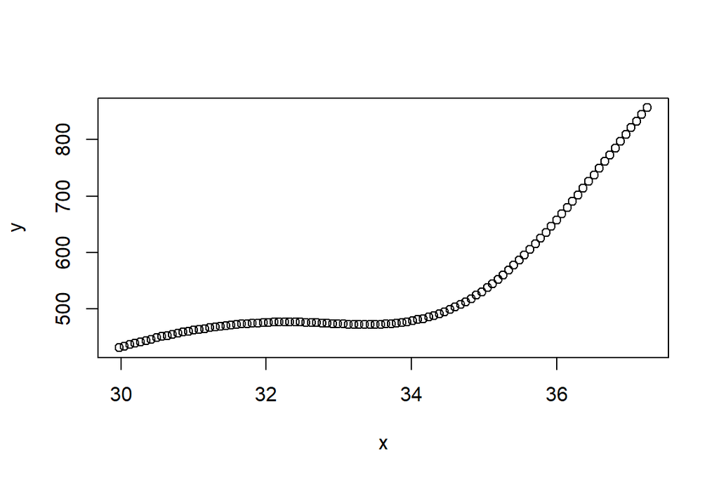

```r
spline.data <- as.data.frame(x= spline_fit$x) |>
  mutate(y = spline_fit$y)|>
  rename(x = `spline_fit$x`)
plot(spline.data)
```

```r
fs.data <- Fstats(spline.data$y~1)
bp.data <- breakpoints(spline.data$y~1)
summary(bp.data)
```

```
##
##   Optimal (m+1)-segment partition:
##
## Call:
## breakpoints.formula(formula = spline.data$y ~ 1)
##
## Breakpoints at observation number:
##
## m = 1               78
## m = 2            70 85
## m = 3         55 70 85
## m = 4   15    55 70 85
## m = 5   15 30 55 70 85
##
## Corresponding to breakdates:
##
## m = 1                     0.78
## m = 2                 0.7 0.85
## m = 3            0.55 0.7 0.85
## m = 4   0.15     0.55 0.7 0.85
## m = 5   0.15 0.3 0.55 0.7 0.85
##
## Fit:
##
## m   0         1         2         3         4         5
## RSS 1289086.6  223458.9   95112.0   79870.4   72776.6   72689.6
## BIC    1239.4    1073.4     997.2     988.9     988.8     997.9
```

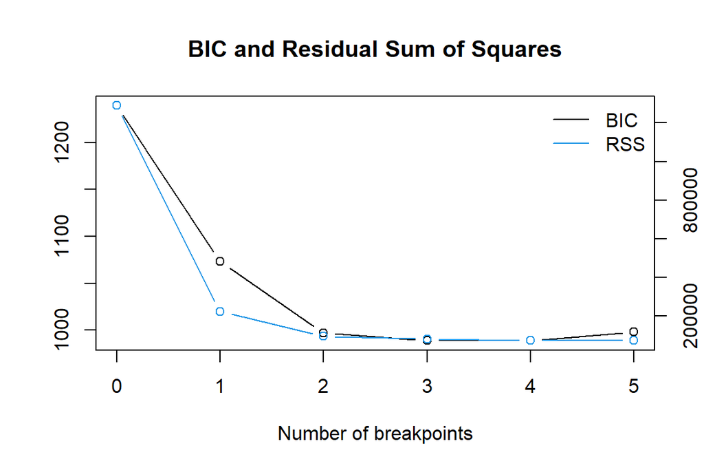

```r
plot(bp.data)
```

```r
breakpoint.values=c(54,70,85); spline.data[breakpoint.values, c("x")]
```

```
## [1] 33.86963 35.04506 36.14703
```

### segement analysis

Use out from strucchange summary to number of breakpoints as well as approximate location of breakpoints

```r
my.lm <- lm(data=spline.data, y ~ x)

spline.data[breakpoint.values, c("x")]
```

```
## [1] 33.86963 35.04506 36.14703
```

```r
my.seg <- segmented(my.lm,
                    seg.Z = ~x,
                    psi=list(x=spline.data[breakpoint.values, c("x")]))
#summary(my.seg)

my.seg$psi ; slope(my.seg)
```

```
##         Initial     Est.     St.Err
## psi1.x 33.86963 31.47574 0.05887590
## psi2.x 35.04506 34.20755 0.02233563
## psi3.x 36.14703 35.37701 0.02265965
```

```
## $x
##             Est. St.Err.  t value CI(95%).l CI(95%).u
## slope1  26.77600 1.37500  19.4730  24.04500    29.507
## slope2   0.81219 0.58750   1.3825  -0.35463     1.979
## slope3  75.59800 2.06930  36.5340  71.48800    79.708
## slope4 154.35000 0.99772 154.7000 152.37000   156.330
```

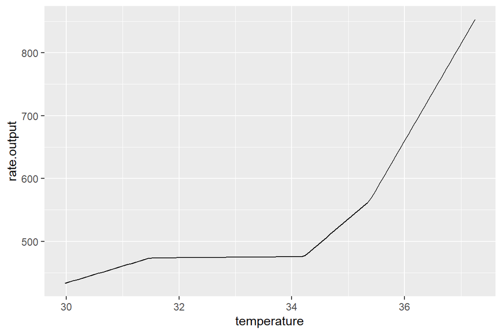

```r
my.fitted <- fitted(my.seg)
my.model <- data.frame(temperature = spline.data$x, rate.output= my.fitted)

ggplot(my.model, aes(x=temperature, y=rate.output)) + geom_line()
```

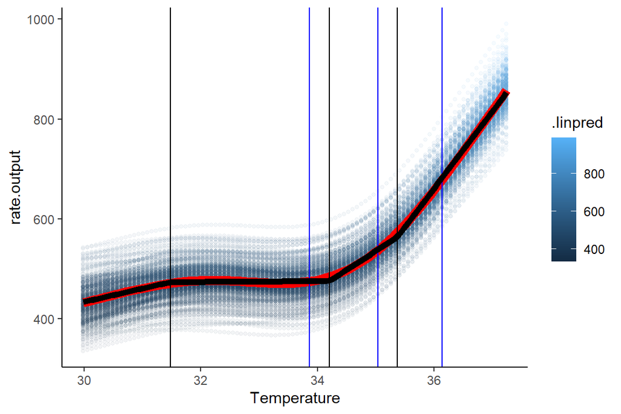

```r
ggplot(posterior_draws, aes(x=Temperature, y=.linpred, color=.linpred)) +
  geom_point(alpha=0.05, size=1) +
  geom_smooth(data=as.data.frame(spline_fit$data), aes(x=x, y=y), color="red",
              size=3) + ylab("rate.output")+
  geom_vline(xintercept = my.seg$psi[1,2]) +
   geom_vline(xintercept = my.seg$psi[2,2])+
  geom_vline(xintercept = my.seg$psi[3,2])+
   geom_vline(xintercept = my.seg$psi[1,1], color="blue") +
  geom_vline(xintercept = my.seg$psi[2,1], color="blue") +
  geom_vline(xintercept = my.seg$psi[3,1], color="blue") +
  geom_line(data=my.model, aes(x=temperature, y=rate.output), color="black", size=2) +
  theme_classic()
```

## Low-latitude - 31C

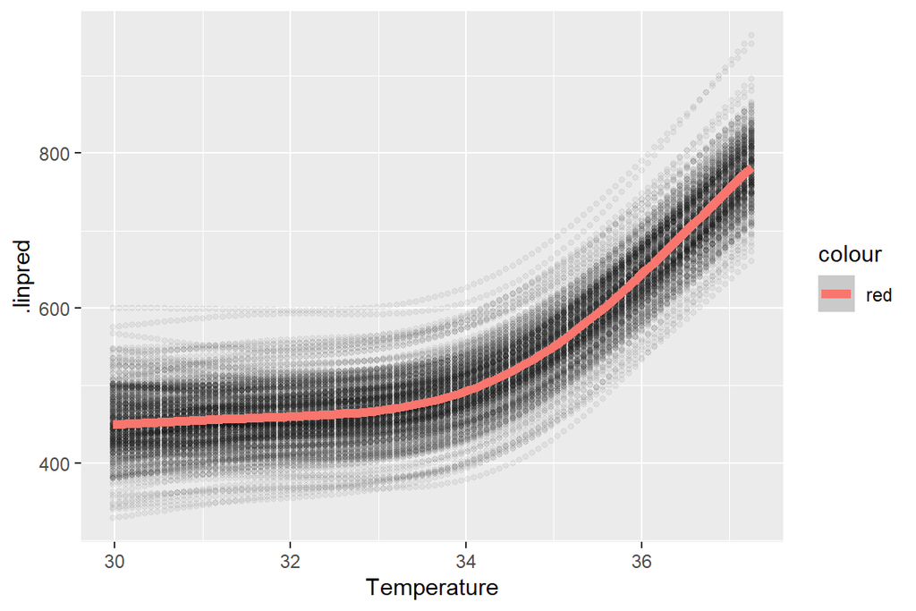

```r
posterior_draws <- lat_resp_dat2 |>
  group_by(region, dev.temp,dev.temp.region) |>
  data_grid(Temperature=seq(from=min(lat_resp_dat2$Temperature),
                          to=max(lat_resp_dat2$Temperature),
                          length.out=100),
            mass=0.00148299) |>
  add_linpred_draws(model1.gamk4,
                   n=300,
                   re_formula=NA) |>
  unite("exp_group", c("region","dev.temp"), remove=FALSE) |>
  filter(dev.temp.region == "31_core")

spline_fit <- smooth.spline(posterior_draws$Temperature, posterior_draws$.linpred, nknots = 4)

ggplot(posterior_draws, aes(x=Temperature, y=.linpred)) +
  geom_point(color="black", alpha=0.05, size=1) +
  geom_smooth(data=as.data.frame(spline_fit$data), aes(x=x, y=y,
                                        color="red"),
              size=2)
```

### strucchange analysis

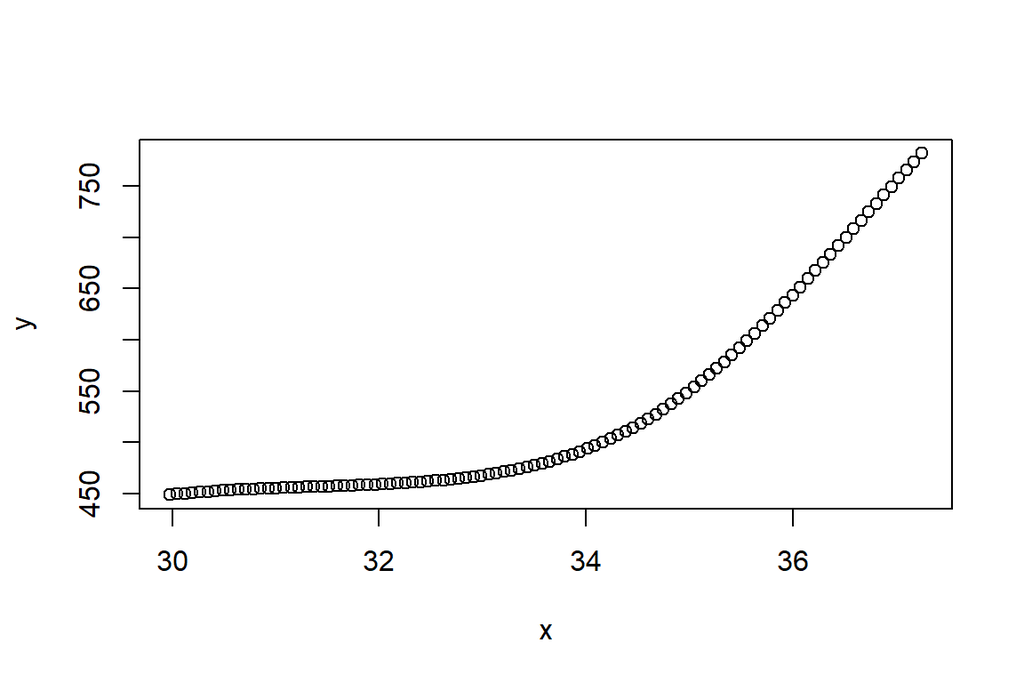

```r
spline.data <- as.data.frame(x= spline_fit$x) |>
  mutate(y = spline_fit$y)|>
  rename(x = `spline_fit$x`)
plot(spline.data)
```

```r
fs.data <- Fstats(spline.data$y~1)
bp.data <- breakpoints(spline.data$y~1)
summary(bp.data)
```

```
##
##   Optimal (m+1)-segment partition:
##
## Call:
## breakpoints.formula(formula = spline.data$y ~ 1)
##
## Breakpoints at observation number:
##
## m = 1            74
## m = 2            64 83
## m = 3         54 70 85
## m = 4      40 55 70 85
## m = 5   22 40 55 70 85
##
## Corresponding to breakdates:
##
## m = 1                 0.74
## m = 2                 0.64 0.83
## m = 3            0.54 0.7  0.85
## m = 4        0.4 0.55 0.7  0.85
## m = 5   0.22 0.4 0.55 0.7  0.85
##
## Fit:
##
## m   0        1        2        3        4        5
## RSS 951373.7 176567.4  73635.2  44061.0  39736.9  39265.8
## BIC   1209.0   1049.8    971.6    929.4    928.3    936.3
```

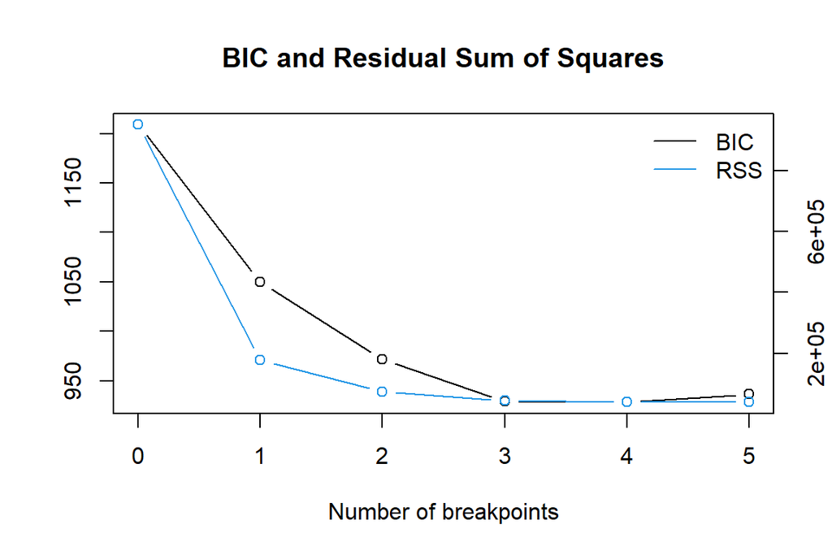

```r
plot(bp.data)
```

```r
breakpoint.values=c(55,70,85); spline.data[breakpoint.values, c("x")]
```

```
## [1] 33.94309 35.04506 36.14703
```

### segement analysis

Use out from strucchange summary to number of breakpoints as well as approximate location of breakpoints

```r
my.lm <- lm(data=spline.data, y ~ x)

spline.data[breakpoint.values, c("x")]
```

```
## [1] 33.94309 35.04506 36.14703
```

```r
my.seg <- segmented(my.lm,
                    seg.Z = ~x,
                    psi=list(x=spline.data[breakpoint.values, c("x")]))
#summary(my.seg)

my.seg$psi ; slope(my.seg)
```

```
##         Initial     Est.     St.Err
## psi1.x 33.94309 33.16127 0.02769747
## psi2.x 35.04506 34.42367 0.02225931
## psi3.x 36.14703 35.50138 0.02594152
```

```
## $x
##            Est. St.Err. t value CI(95%).l CI(95%).u
## slope1   5.4424 0.21502  25.311    5.0153    5.8694
## slope2  33.1200 0.89665  36.937   31.3390   34.9010
## slope3  75.5130 1.08240  69.767   73.3630   77.6630
## slope4 108.9600 0.53408 204.020  107.9000  110.0300
```

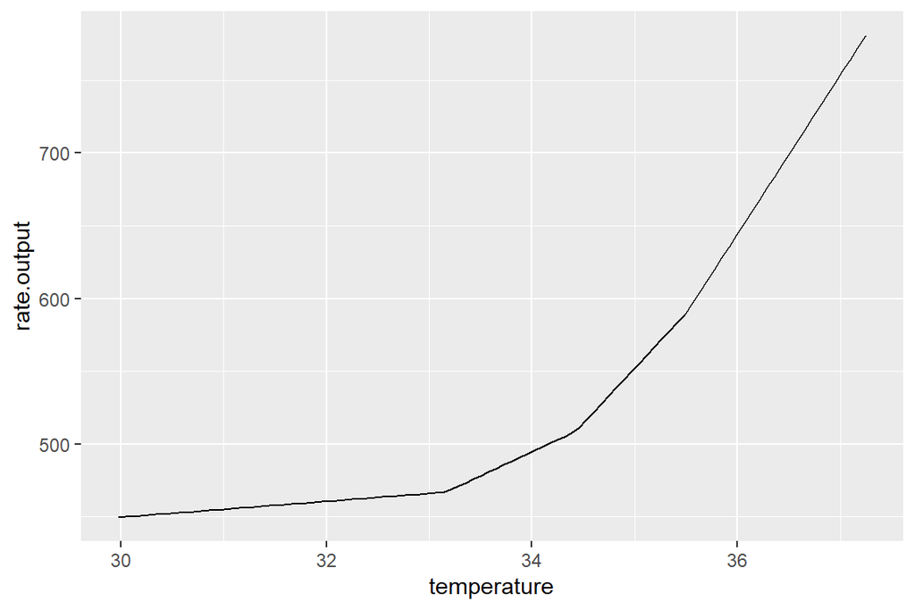

```r
my.fitted <- fitted(my.seg)
my.model <- data.frame(temperature = spline.data$x, rate.output= my.fitted)

ggplot(my.model, aes(x=temperature, y=rate.output)) + geom_line()
```

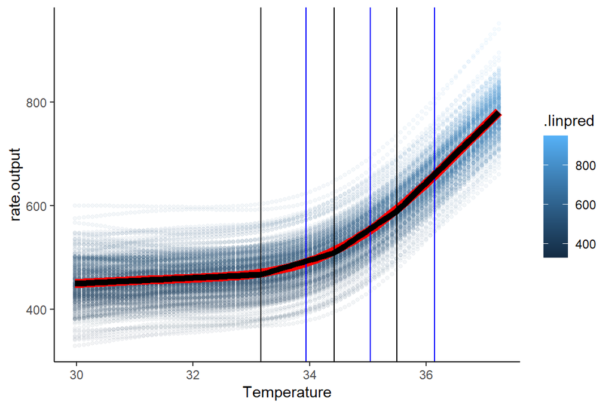

```r
ggplot(posterior_draws, aes(x=Temperature, y=.linpred, color=.linpred)) +
  geom_point(alpha=0.05, size=1) +
  geom_smooth(data=as.data.frame(spline_fit$data), aes(x=x, y=y), color="red",
              size=3) + ylab("rate.output")+
  geom_vline(xintercept = my.seg$psi[1,2]) +
   geom_vline(xintercept = my.seg$psi[2,2])+
  geom_vline(xintercept = my.seg$psi[3,2])+
   geom_vline(xintercept = my.seg$psi[1,1], color="blue") +
  geom_vline(xintercept = my.seg$psi[2,1], color="blue") +
  geom_vline(xintercept = my.seg$psi[3,1], color="blue") +
  geom_line(data=my.model, aes(x=temperature, y=rate.output), color="black", size=2) +
  theme_classic()
```

## High-latitude - 28C

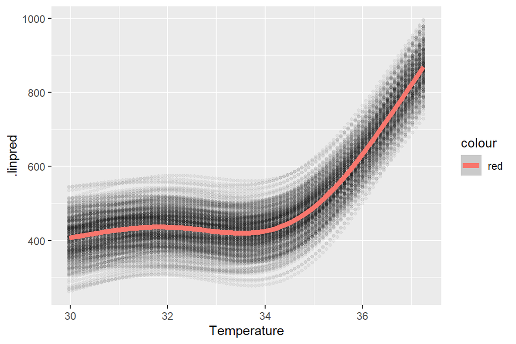

```r
posterior_draws <- lat_resp_dat2 |>
  group_by(region, dev.temp,dev.temp.region) |>
  data_grid(Temperature=seq(from=min(lat_resp_dat2$Temperature),
                          to=max(lat_resp_dat2$Temperature),
                          length.out=100),
            mass=0.00148299) |>
  add_linpred_draws(model1.gamk4,
                   n=300,
                   re_formula=NA) |>
  unite("exp_group", c("region","dev.temp"), remove=FALSE) |>
  filter(dev.temp.region == "28_leading")

spline_fit <- smooth.spline(posterior_draws$Temperature, posterior_draws$.linpred, nknots = 4)

ggplot(posterior_draws, aes(x=Temperature, y=.linpred)) +
  geom_point(color="black", alpha=0.05, size=1) +
  geom_smooth(data=as.data.frame(spline_fit$data), aes(x=x, y=y,
                                        color="red"),
              size=2)
```

### strucchange analysis

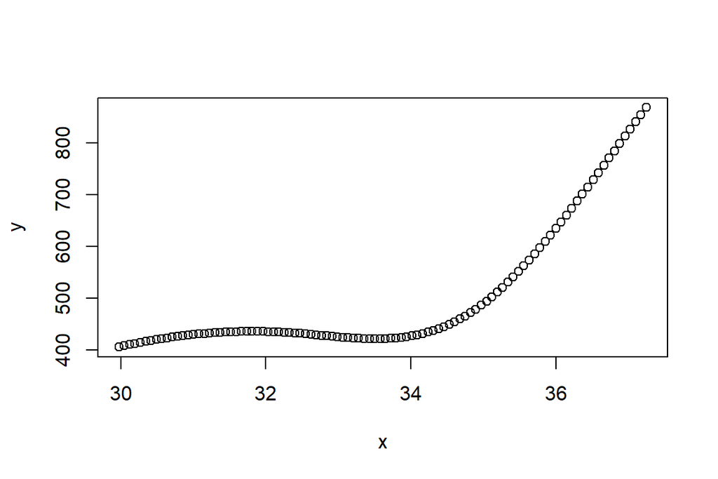

```r
spline.data <- as.data.frame(x= spline_fit$x) |>
  mutate(y = spline_fit$y)|>
  rename(x = `spline_fit$x`)
plot(spline.data)
```

```r
fs.data <- Fstats(spline.data$y~1)
bp.data <- breakpoints(spline.data$y~1)
summary(bp.data)
```

```
##
##   Optimal (m+1)-segment partition:
##
## Call:
## breakpoints.formula(formula = spline.data$y ~ 1)
##
## Breakpoints at observation number:
##
## m = 1               79
## m = 2            70 85
## m = 3         55 70 85
## m = 4   15    55 70 85
## m = 5   15 38 55 70 85
##
## Corresponding to breakdates:
##
## m = 1                      0.79
## m = 2                  0.7 0.85
## m = 3             0.55 0.7 0.85
## m = 4   0.15      0.55 0.7 0.85
## m = 5   0.15 0.38 0.55 0.7 0.85
##
## Fit:
##
## m   0       1       2       3       4       5
## RSS 1612756  264488  108644   99987   98860   97905
## BIC    1262    1090    1010    1011    1019    1028
```

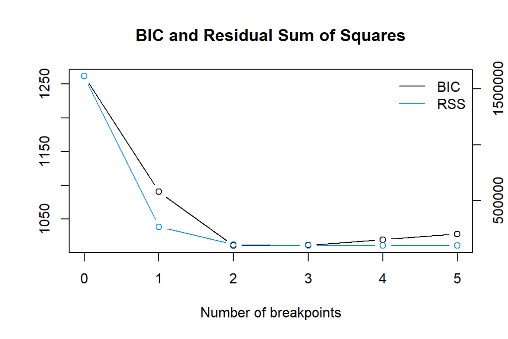

```r
plot(bp.data)
```

```r
breakpoint.values=c(55,70,85); spline.data[breakpoint.values, c("x")]
```

```
## [1] 33.94309 35.04506 36.14703
```

### segement analysis

Use out from strucchange summary to number of breakpoints as well as approximate location of breakpoints

```r
my.lm <- lm(data=spline.data, y ~ x)

spline.data[breakpoint.values, c("x")]
```

```
## [1] 33.94309 35.04506 36.14703
```

```r
my.seg <- segmented(my.lm,
                    seg.Z = ~x,
                    psi=list(x=spline.data[breakpoint.values, c("x")]))
#summary(my.seg)

my.seg$psi ; slope(my.seg)
```

```
##         Initial     Est.     St.Err
## psi1.x 33.94309 34.20914 0.05958793
## psi2.x 35.04506 34.93752 0.07430573
## psi3.x 36.14703 35.75777 0.08572172
```

```
## $x
##           Est. St.Err. t value CI(95%).l CI(95%).u
## slope1   1.386 0.61625  2.2490   0.16205    2.6099
## slope2  66.933 8.64990  7.7379  49.75300   84.1120
## slope3 135.080 7.49110 18.0320 120.20000  149.9600
## slope4 186.000 2.83140 65.6920 180.37000  191.6200
```

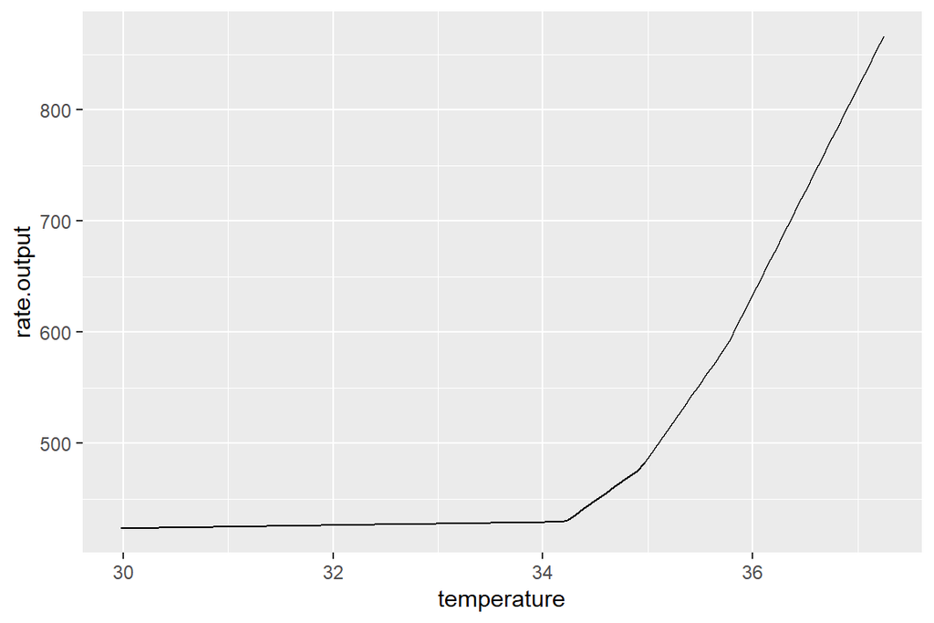

```r
my.fitted <- fitted(my.seg)
my.model <- data.frame(temperature = spline.data$x, rate.output= my.fitted)

ggplot(my.model, aes(x=temperature, y=rate.output)) + geom_line()
```

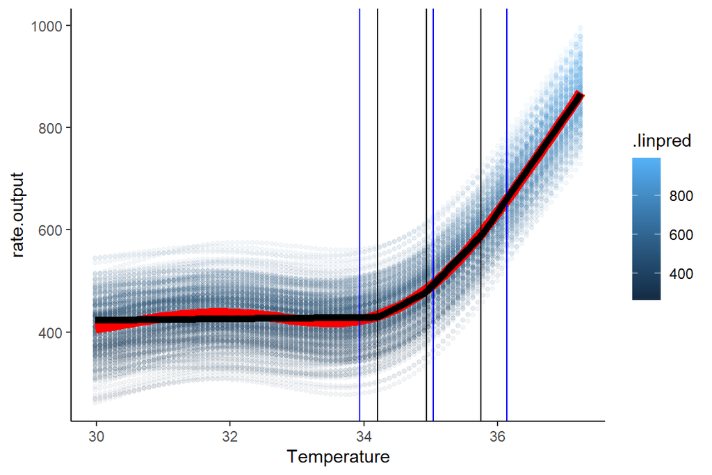

```r
ggplot(posterior_draws, aes(x=Temperature, y=.linpred, color=.linpred)) +
  geom_point(alpha=0.05, size=1) +
  geom_smooth(data=as.data.frame(spline_fit$data), aes(x=x, y=y), color="red",
              size=3) + ylab("rate.output")+
  geom_vline(xintercept = my.seg$psi[1,2]) +
   geom_vline(xintercept = my.seg$psi[2,2])+
  geom_vline(xintercept = my.seg$psi[3,2])+
   geom_vline(xintercept = my.seg$psi[1,1], color="blue") +
  geom_vline(xintercept = my.seg$psi[2,1], color="blue") +
  geom_vline(xintercept = my.seg$psi[3,1], color="blue") +
  geom_line(data=my.model, aes(x=temperature, y=rate.output), color="black", size=2) +
  theme_classic()
```

## High-latitude - 30C

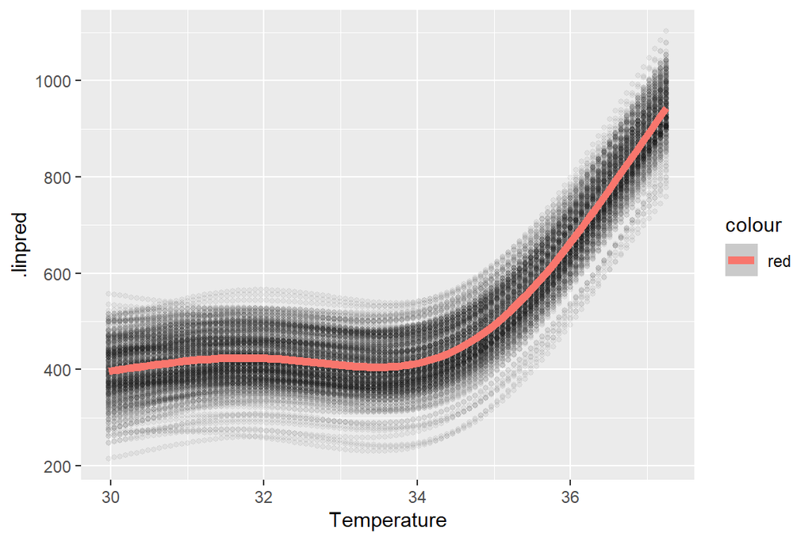

```r
posterior_draws <- lat_resp_dat2 |>
  group_by(region, dev.temp,dev.temp.region) |>
  data_grid(Temperature=seq(from=min(lat_resp_dat2$Temperature),
                          to=max(lat_resp_dat2$Temperature),
                          length.out=100),
            mass=0.00148299) |>
  add_linpred_draws(model1.gamk4,
                   n=300,
                   re_formula=NA) |>
  unite("exp_group", c("region","dev.temp"), remove=FALSE) |>
  filter(dev.temp.region == "30_leading")

spline_fit <- smooth.spline(posterior_draws$Temperature, posterior_draws$.linpred, nknots = 4)

ggplot(posterior_draws, aes(x=Temperature, y=.linpred)) +
  geom_point(color="black", alpha=0.05, size=1) +
  geom_smooth(data=as.data.frame(spline_fit$data), aes(x=x, y=y,
                                        color="red"),
              size=2)
```

### strucchange analysis

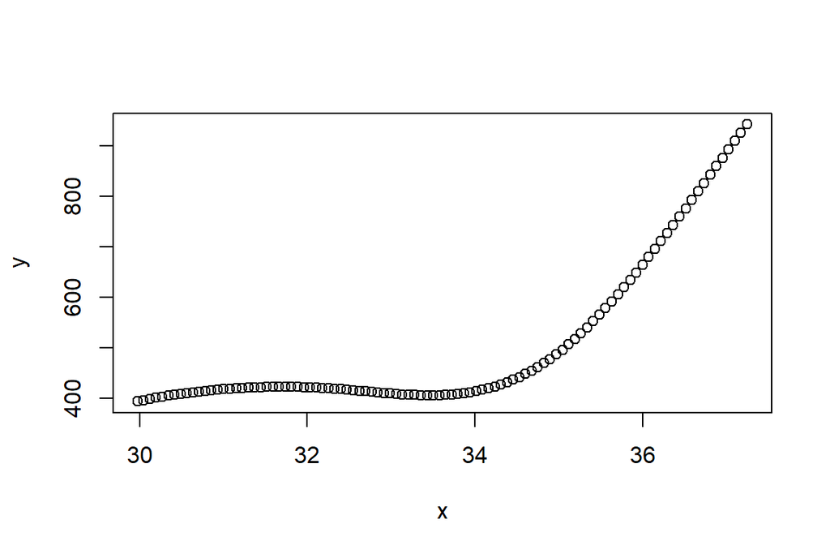

```r
spline.data <- as.data.frame(x= spline_fit$x) |>
  mutate(y = spline_fit$y)|>
  rename(x = `spline_fit$x`)
plot(spline.data)
```

```r
fs.data <- Fstats(spline.data$y~1)
bp.data <- breakpoints(spline.data$y~1)
summary(bp.data)
```

```
##
##   Optimal (m+1)-segment partition:
##
## Call:
## breakpoints.formula(formula = spline.data$y ~ 1)
##
## Breakpoints at observation number:
##
## m = 1               78
## m = 2            70 85
## m = 3         55 70 85
## m = 4   15    55 70 85
## m = 5   15 37 55 70 85
##
## Corresponding to breakdates:
##
## m = 1                      0.78
## m = 2                  0.7 0.85
## m = 3             0.55 0.7 0.85
## m = 4   0.15      0.55 0.7 0.85
## m = 5   0.15 0.37 0.55 0.7 0.85
##
## Fit:
##
## m   0       1       2       3       4       5
## RSS 2321698  379911  154479  140940  140332  138992
## BIC    1298    1126    1046    1046    1054    1063
```

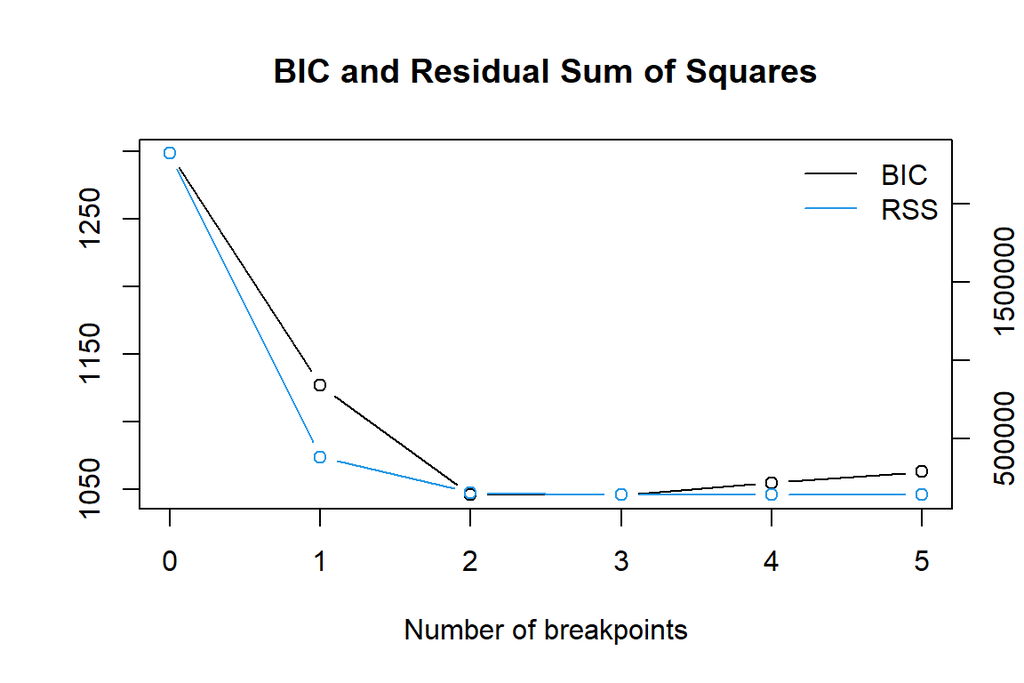

```r
plot(bp.data)
```

```r
breakpoint.values=c(55,70,85); spline.data[breakpoint.values, c("x")]
```

```
## [1] 33.94309 35.04506 36.14703
```

### segement analysis

Use out from strucchange summary to number of breakpoints as well as approximate location of breakpoints

```r
my.lm <- lm(data=spline.data, y ~ x)

spline.data[breakpoint.values, c("x")]
```

```
## [1] 33.94309 35.04506 36.14703
```

```r
my.seg <- segmented(my.lm,
                    seg.Z = ~x,
                    psi=list(x=spline.data[breakpoint.values, c("x")]))
#summary(my.seg)

my.seg$psi ; slope(my.seg)
```

```
##         Initial     Est.     St.Err
## psi1.x 33.94309 34.13619 0.04916754
## psi2.x 35.04506 34.92604 0.06043609
## psi3.x 36.14703 35.75675 0.07509539
```

```
## $x
##             Est. St.Err.  t value CI(95%).l CI(95%).u
## slope1   0.24934 0.64634  0.38578   -1.0343     1.533
## slope2  78.34700 7.65450 10.23500   63.1450    93.550
## slope3 161.85000 7.65450 21.14400  146.6400   177.050
## slope4 221.18000 2.89310 76.44900  215.4300   226.920
```

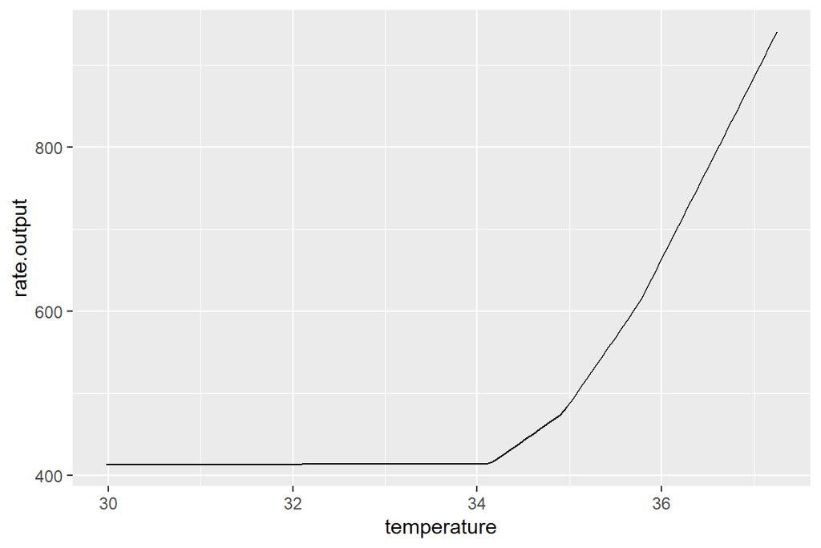

```r
my.fitted <- fitted(my.seg)
my.model <- data.frame(temperature = spline.data$x, rate.output= my.fitted)

ggplot(my.model, aes(x=temperature, y=rate.output)) + geom_line()
```

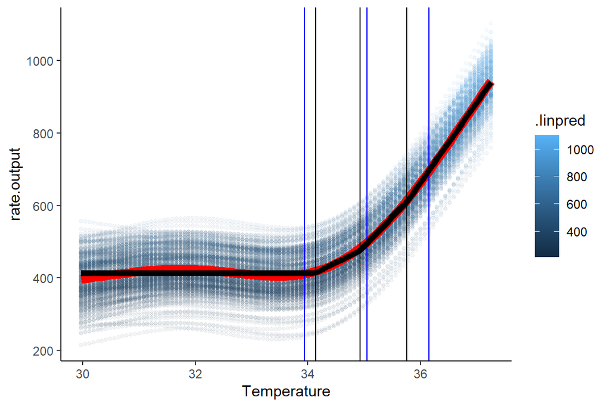

```r
ggplot(posterior_draws, aes(x=Temperature, y=.linpred, color=.linpred)) +
  geom_point(alpha=0.05, size=1) +
  geom_smooth(data=as.data.frame(spline_fit$data), aes(x=x, y=y), color="red",
              size=3) + ylab("rate.output")+
  geom_vline(xintercept = my.seg$psi[1,2]) +
   geom_vline(xintercept = my.seg$psi[2,2])+
  geom_vline(xintercept = my.seg$psi[3,2])+
   geom_vline(xintercept = my.seg$psi[1,1], color="blue") +
  geom_vline(xintercept = my.seg$psi[2,1], color="blue") +
  geom_vline(xintercept = my.seg$psi[3,1], color="blue") +
  geom_line(data=my.model, aes(x=temperature, y=rate.output), color="black", size=2) +
  theme_classic()
```

## High-latitude - 31C

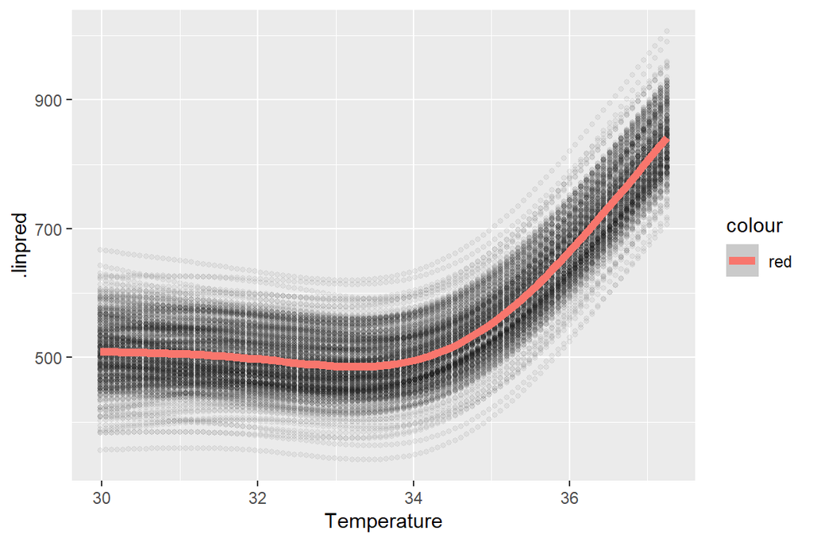

```r
posterior_draws <- lat_resp_dat2 |>
  group_by(region, dev.temp,dev.temp.region) |>
  data_grid(Temperature=seq(from=min(lat_resp_dat2$Temperature),
                          to=max(lat_resp_dat2$Temperature),
                          length.out=100),
            mass=0.00148299) |>
  add_linpred_draws(model1.gamk4,
                   n=300,
                   re_formula=NA) |>
  unite("exp_group", c("region","dev.temp"), remove=FALSE) |>
  filter(dev.temp.region == "31_leading")

spline_fit <- smooth.spline(posterior_draws$Temperature, posterior_draws$.linpred, nknots = 4)

ggplot(posterior_draws, aes(x=Temperature, y=.linpred)) +
  geom_point(color="black", alpha=0.05, size=1) +
  geom_smooth(data=as.data.frame(spline_fit$data), aes(x=x, y=y,
                                        color="red"),
              size=2)
```

### strucchange analysis

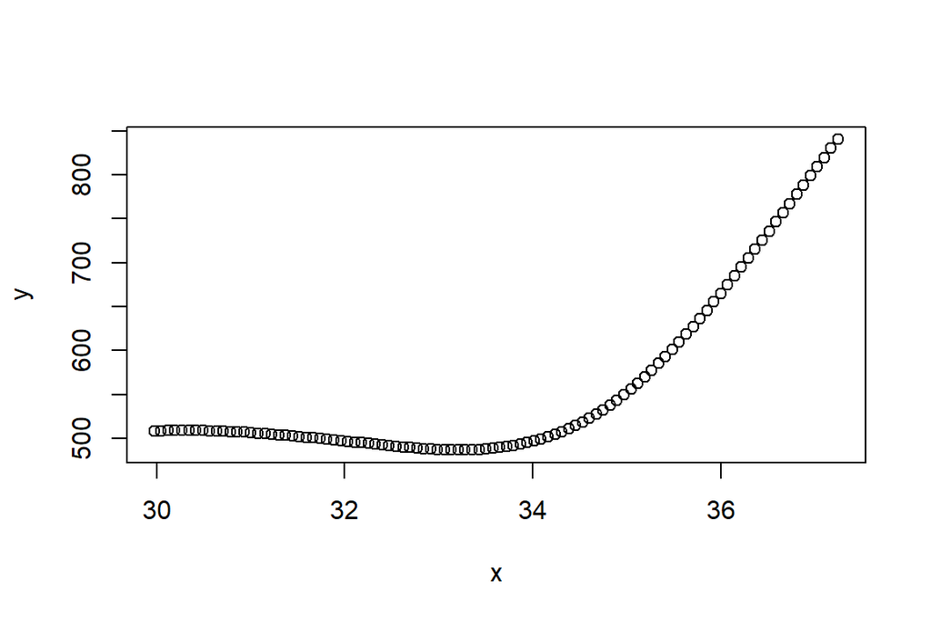

```r
spline.data <- as.data.frame(x= spline_fit$x) |>
  mutate(y = spline_fit$y)|>
  rename(x = `spline_fit$x`)
plot(spline.data)
```

```r
fs.data <- Fstats(spline.data$y~1)
bp.data <- breakpoints(spline.data$y~1)
summary(bp.data)
```

```
##
##   Optimal (m+1)-segment partition:
##
## Call:
## breakpoints.formula(formula = spline.data$y ~ 1)
##
## Breakpoints at observation number:
##
## m = 1               78
## m = 2            70 85
## m = 3         55 70 85
## m = 4      26 55 70 85
## m = 5   17 32 55 70 85
##
## Corresponding to breakdates:
##
## m = 1                      0.78
## m = 2                  0.7 0.85
## m = 3             0.55 0.7 0.85
## m = 4        0.26 0.55 0.7 0.85
## m = 5   0.17 0.32 0.55 0.7 0.85
##
## Fit:
##
## m   0        1        2        3        4        5
## RSS 995002.7 164741.2  67258.5  60638.9  57568.3  57272.2
## BIC   1213.5   1042.9    962.5    961.4    965.4    974.1
```

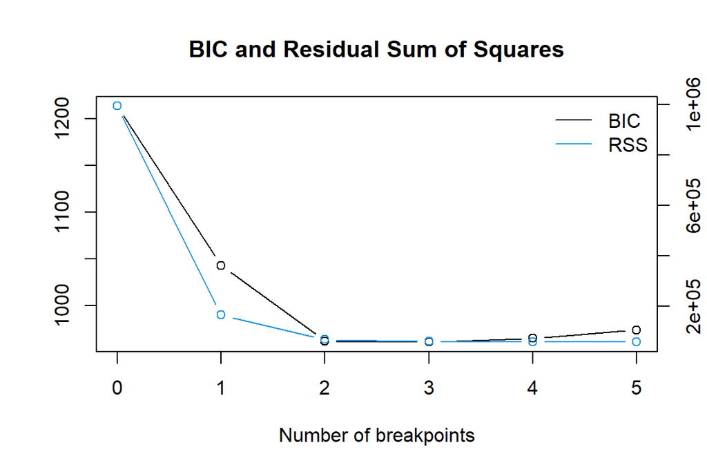

```r
plot(bp.data)
```

```r
breakpoint.values=c(55,70,85); spline.data[breakpoint.values, c("x")]
```

```
## [1] 33.94309 35.04506 36.14703
```

### segement analysis

Use out from strucchange summary to number of breakpoints as well as approximate location of breakpoints

```r
my.lm <- lm(data=spline.data, y ~ x)

spline.data[breakpoint.values, c("x")]
```

```
## [1] 33.94309 35.04506 36.14703
```

```r
my.seg <- segmented(my.lm,
                    seg.Z = ~x,
                    psi=list(x=spline.data[breakpoint.values, c("x")]))
#summary(my.seg)

my.seg$psi ; slope(my.seg)
```

```
##         Initial     Est.     St.Err
## psi1.x 33.94309 33.54958 0.02768565
## psi2.x 35.04506 34.58443 0.02256263
## psi3.x 36.14703 35.58101 0.02554307
```

```
## $x
##            Est. St.Err. t value CI(95%).l CI(95%).u
## slope1  -7.8319 0.24673 -31.743   -8.3219   -7.3418
## slope2  31.0790 1.61930  19.193   27.8630   34.2960
## slope3  91.3370 1.61930  56.403   88.1200   94.5530
## slope4 138.6300 0.76778 180.560  137.1100  140.1600
```

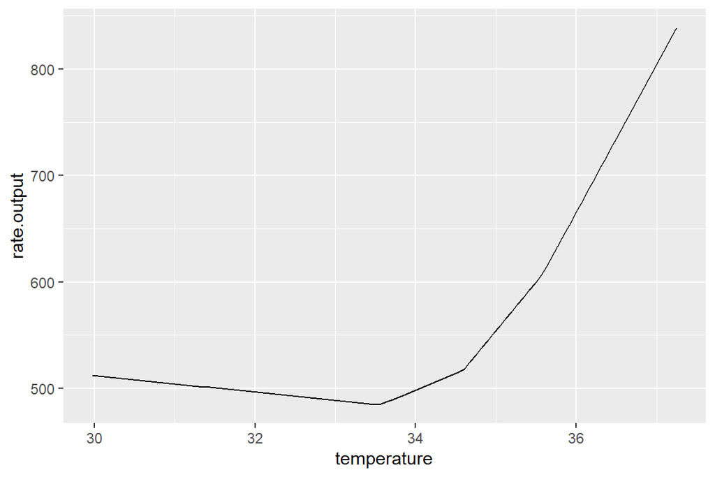

```r
my.fitted <- fitted(my.seg)
my.model <- data.frame(temperature = spline.data$x, rate.output= my.fitted)

ggplot(my.model, aes(x=temperature, y=rate.output)) + geom_line()
```

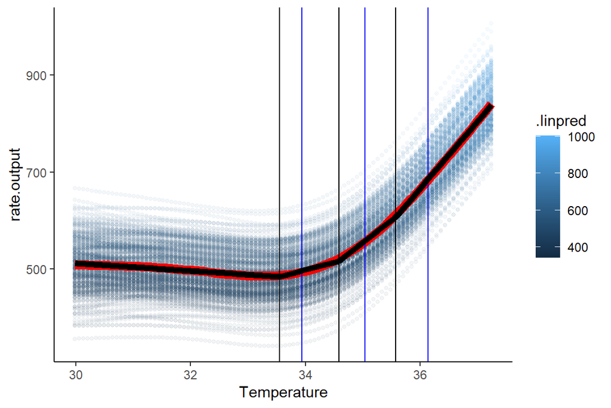

```r
ggplot(posterior_draws, aes(x=Temperature, y=.linpred, color=.linpred)) +
  geom_point(alpha=0.05, size=1) +
  geom_smooth(data=as.data.frame(spline_fit$data), aes(x=x, y=y), color="red",
              size=3) + ylab("rate.output")+
  geom_vline(xintercept = my.seg$psi[1,2]) +
   geom_vline(xintercept = my.seg$psi[2,2])+
  geom_vline(xintercept = my.seg$psi[3,2])+
   geom_vline(xintercept = my.seg$psi[1,1], color="blue") +
  geom_vline(xintercept = my.seg$psi[2,1], color="blue") +
  geom_vline(xintercept = my.seg$psi[3,1], color="blue") +
  geom_line(data=my.model, aes(x=temperature, y=rate.output), color="black", size=2) +
  theme_classic()
```